# Project: Wrangle and Analyse Twitter's WeRateDogs

- Introduction
- Data Wrangling Process
- Gathering Data
- Assessing Data
- Cleaning Data
- Exploratory Data Analysis

## Introduction

In this project, the **Twitter's WeRateDogs** data is wrangled and analysed.

First, the data is **gathered**. The data comes from three different sources: a pre-downloaded file, a file programmatically downloaded from the Internet, and querying Twitter's API.

Then, the data will be **assessed** visually and programmatically to identify any tidiness and quality issues. Subsequently, the data is then **cleaned** to address these issues.

Finally, using the cleaned data, the **data analysis** process can be carried out to gain interesting insights about Twitter's WeRateDogs.

```python
# Importing the main packages for this project

import pandas as pd
import numpy as np
import matplotlib.pyplot as plt

%matplotlib inline
```

## Data Wrangling Process

The data wrangling process consist of three steps:

- **Gathering Data**
- **Assessing Data**
- **Cleaning Data**.

```python
# Importing the main packages for the data wrangling process

import requests
import tweepy
import json
import time
```

### Gathering Data

The data for this project comes from three different sources using three different methods.

1. **WeRateDogs Twitter Archive**, obtained by **downloading it manually** on [twitter_archive_enhanced.csv](https://d17h27t6h515a5.cloudfront.net/topher/2017/August/59a4e958_twitter-archive-enhanced/twitter-archive-enhanced.csv)
2. **Tweet Image Predictions**, i.e., what breed of dog is present in each tweet according to a neural network. This file (image_predictions.tsv) is hosted on Udacity's servers and will be **downloaded programmatically** using the Requests library and the following URL: https://d17h27t6h515a5.cloudfront.net/topher/2017/August/599fd2ad_image-predictions/image-predictions.tsv.
3. **Tweet Information**, including each tweet's retweet count, favourite ("like") count, and any additional interesting data. This is obtained by **querying Twitter's API**.

#### 1. WeRateDogs archive

File `twitter-archive-enhanced.csv` is already downloaded manually.

```python
# create DF for WeRateDogs Twitter archive (file already downloaded manually)
df_dogs_archive = pd.read_csv("twitter-archive-enhanced.csv")
df_dogs_archive.head()
```

|  | tweet_id | in_reply_to_status_id | in_reply_to_user_id | timestamp | source | text | retweeted_status_id | retweeted_status_user_id | retweeted_status_timestamp | expanded_urls | rating_numerator | rating_denominator | name | doggo | floofer | pupper | puppo |
| --- | --- | --- | --- | --- | --- | --- | --- | --- | --- | --- | --- | --- | --- | --- | --- | --- | --- |
| 0 | 892420643555336193 | nan | nan | 2017-08-01 16:23:56 +0000 | <a href="http://twitter.com/download/iphone" rel="nofollow">Twitter for iPhone</a> | This is Phineas. He's a mystical boy. Only ever appears in the hole of a donut. 13/10 https://t.co/MgUWQ76dJU | nan | nan | NaN | https://twitter.com/dog_rates/status/892420643555336193/photo/1 | 13 | 10 | Phineas | None | None | None | None |
| 1 | 892177421306343426 | nan | nan | 2017-08-01 00:17:27 +0000 | <a href="http://twitter.com/download/iphone" rel="nofollow">Twitter for iPhone</a> | This is Tilly. She's just checking pup on you. Hopes you're doing ok. If not, she's available for pats, snugs, boops, the whole bit. 13/10 https://t.co/0Xxu71qeIV | nan | nan | NaN | https://twitter.com/dog_rates/status/892177421306343426/photo/1 | 13 | 10 | Tilly | None | None | None | None |
| 2 | 891815181378084864 | nan | nan | 2017-07-31 00:18:03 +0000 | <a href="http://twitter.com/download/iphone" rel="nofollow">Twitter for iPhone</a> | This is Archie. He is a rare Norwegian Pouncing Corgo. Lives in the tall grass. You never know when one may strike. 12/10 https://t.co/wUnZnhtVJB | nan | nan | NaN | https://twitter.com/dog_rates/status/891815181378084864/photo/1 | 12 | 10 | Archie | None | None | None | None |
| 3 | 891689557279858688 | nan | nan | 2017-07-30 15:58:51 +0000 | <a href="http://twitter.com/download/iphone" rel="nofollow">Twitter for iPhone</a> | This is Darla. She commenced a snooze mid meal. 13/10 happens to the best of us https://t.co/tD36da7qLQ | nan | nan | NaN | https://twitter.com/dog_rates/status/891689557279858688/photo/1 | 13 | 10 | Darla | None | None | None | None |
| 4 | 891327558926688256 | nan | nan | 2017-07-29 16:00:24 +0000 | <a href="http://twitter.com/download/iphone" rel="nofollow">Twitter for iPhone</a> | This is Franklin. He would like you to stop calling him "cute." He is a very fierce shark and should be respected as such. 12/10 #BarkWeek https://t.co/AtUZn91f7f | nan | nan | NaN | https://twitter.com/dog_rates/status/891327558926688256/photo/1,https://twitter.com/dog_rates/status/891327558926688256/photo/1 | 12 | 10 | Franklin | None | None | None | None |

#### 2. Tweet Image Prediction from Udacity server

The file `image-predictions.tsv` is hosted on the Udacity server and can be downloaded programmatically using the `requests` library, then saved to file, and then DataFrame is created.

```python
url = "https://d17h27t6h515a5.cloudfront.net/topher/2017/August/599fd2ad_image-predictions/image-predictions.tsv"
response = requests.get(url)

with open("image-predictions.tsv", mode="wb") as file:
    file.write(response.content)
```

```python
# create DF for tweet image prediction
df_image_pred = pd.read_csv("image-predictions.tsv", sep="\t")
df_image_pred.head()
```

|  | tweet_id | jpg_url | img_num | p1 | p1_conf | p1_dog | p2 | p2_conf | p2_dog | p3 | p3_conf | p3_dog |
| --- | --- | --- | --- | --- | --- | --- | --- | --- | --- | --- | --- | --- |
| 0 | 666020888022790149 | https://pbs.twimg.com/media/CT4udn0WwAA0aMy.jpg | 1 | Welsh_springer_spaniel | 0.47 | True | collie | 0.16 | True | Shetland_sheepdog | 0.06 | True |
| 1 | 666029285002620928 | https://pbs.twimg.com/media/CT42GRgUYAA5iDo.jpg | 1 | redbone | 0.51 | True | miniature_pinscher | 0.07 | True | Rhodesian_ridgeback | 0.07 | True |
| 2 | 666033412701032449 | https://pbs.twimg.com/media/CT4521TWwAEvMyu.jpg | 1 | German_shepherd | 0.60 | True | malinois | 0.14 | True | bloodhound | 0.12 | True |
| 3 | 666044226329800704 | https://pbs.twimg.com/media/CT5Dr8HUEAA-lEu.jpg | 1 | Rhodesian_ridgeback | 0.41 | True | redbone | 0.36 | True | miniature_pinscher | 0.22 | True |
| 4 | 666049248165822465 | https://pbs.twimg.com/media/CT5IQmsXIAAKY4A.jpg | 1 | miniature_pinscher | 0.56 | True | Rottweiler | 0.24 | True | Doberman | 0.15 | True |

#### 3. Tweet information by querying Twitter API

A developer account is created and approved at Twitter. Then an app is created, where the keys and tokens can be obtained.

Using the tweet IDs in the WeRateDogs Twitter archive, query the Twitter API for each tweet's JSON data using Python's Tweepy library. This is then stored in a file. Interesting data is extracted and this is then read into a pandas DataFrame.

*Note: the code below shows how to obtain data by querying Twitter API. The actual file used is "tweet_json.txt" provided by Udacity. This will be used for the analysis for the remainder of the project (and not the one queried from Twitter). This allows for consistency and reproducibility.*

```python
# Consumer and access keys, tokens, and secrets from Twitter Developer App
# These are hidden to comply with Twitter's API terms and conditions
consumer_key = "" # Hidden
consumer_secret = ""
access_token = ""
access_secret = ""
```

```python
auth = tweepy.OAuthHandler(consumer_key, consumer_secret)
auth.set_access_token(access_token, access_secret)

# Twitter's has a 15 minute rate limit, and the query will take longer
# so API will continue
api = tweepy.API(auth, wait_on_rate_limit=True, wait_on_rate_limit_notify=True)
```

```python
# Query Twitter's API for JSON data for each tweet ID in the Twitter archive
# Each tweet's JSON data is written to its own line.
# Commented out as it is not required once the file is created

#count = 0
#fails = {}
#start = time.time()

#with open("tweet_json_api_created.txt", "w") as outfile:
#    for tweet in we_rate_dogs.tweet_id:
#        count += 1
#        try:
#            tweet_api = api.get_status(tweet, tweet_mode='extended')
#            #tweet_api returns a Status object. To access the JSON file, use ._json
#            json.dump(tweet_api._json, outfile)
#            outfile.write("\n")
#            print("Success - count {}: {}".format(count, tweet))
        # Skip deleted tweets
#        except tweepy.TweepError as e:
#            fails[tweet] = e
#            print("Fail - count {}: {}".format(count, tweet))
#            pass

#end = time.time()
#print(end - start)
```

*Note: for consistency and reproducibility, the remainder of the project will use "tweet_json.txt" provided by Udacity, and not the one queried from Twitter API above.*

```python
# tweet_json.txt file is read tweet by tweet to extract interesting information:
# tweet ID, retweet count, and favorite count. Add these into a list
df_list = []

with open("tweet_json.txt") as json_file:
    for line in json_file:
        tweet = json.loads(line)
        tweet_id = tweet["id"]
        retweet_count = tweet["retweet_count"]
        favorite_count = tweet["favorite_count"]
        df_list.append({"tweet_id": tweet_id,
                        "retweet_count": retweet_count,
                        "favorite_count": favorite_count})
```

```python
df_tweets = pd.DataFrame(df_list, columns=["tweet_id", "retweet_count",
                                           "favorite_count"])
df_tweets.head()
```

|  | tweet_id | retweet_count | favorite_count |
| --- | --- | --- | --- |
| 0 | 892420643555336193 | 8853 | 39467 |
| 1 | 892177421306343426 | 6514 | 33819 |
| 2 | 891815181378084864 | 4328 | 25461 |
| 3 | 891689557279858688 | 8964 | 42908 |
| 4 | 891327558926688256 | 9774 | 41048 |

### Assessing Data

Assessing data reveals issues that can be categorised into two main types:

- **Quality issues**: due to the data's content. This is also known as dirty data or low quality data
- **Tidiness issues**: due to the data's structure. This is also known as untidy data

There are two ways to identify such issues: **visual** and **programmatic assessments**.

The following data quality dimensions will help guide through assessing and cleaning data:

- **Completeness** - is the data complete?
- **Validity** - are all records valid and confrom to a defined schema?
- **Accuracy** - is all the data accurate even if they are valid?
- **Consistency** - do similar data within and across tables have a consistent format?

The data quality and tidiness issues will be summarised at the end of this section.

*Dataset 1: WeRateDogs archive `df_dogs_archive`*

Column descriptions:

- `tweet_id`: last part of the tweet URL after "status/", e.g. https://twitter.com/dog_rates/status/889531135344209921

`doggo`, `pupper`, `floofer`, and `puppo` refers to the different dog stages. (via #WeRateDogs book on Amazon)

- `doggo`: a big pupper, usually older. May behave like a pupper, and is a pupper that has its life in order.
- `pupper`: a small doggo, usually younger. Can be equally, or even more mature than doggo. A doggo that is inexperienced and unprepared for responsibilities.
- `puppo`: transitional phase between a pupper and doggo. It is the equivalent of a teenager
- `floofer`: any dog really, but commonly used for dogs with excessive hair.

```python
df_dogs_archive.head()
```

|  | tweet_id | in_reply_to_status_id | in_reply_to_user_id | timestamp | source | text | retweeted_status_id | retweeted_status_user_id | retweeted_status_timestamp | expanded_urls | rating_numerator | rating_denominator | name | doggo | floofer | pupper | puppo |
| --- | --- | --- | --- | --- | --- | --- | --- | --- | --- | --- | --- | --- | --- | --- | --- | --- | --- |
| 0 | 892420643555336193 | nan | nan | 2017-08-01 16:23:56 +0000 | <a href="http://twitter.com/download/iphone" rel="nofollow">Twitter for iPhone</a> | This is Phineas. He's a mystical boy. Only ever appears in the hole of a donut. 13/10 https://t.co/MgUWQ76dJU | nan | nan | NaN | https://twitter.com/dog_rates/status/892420643555336193/photo/1 | 13 | 10 | Phineas | None | None | None | None |
| 1 | 892177421306343426 | nan | nan | 2017-08-01 00:17:27 +0000 | <a href="http://twitter.com/download/iphone" rel="nofollow">Twitter for iPhone</a> | This is Tilly. She's just checking pup on you. Hopes you're doing ok. If not, she's available for pats, snugs, boops, the whole bit. 13/10 https://t.co/0Xxu71qeIV | nan | nan | NaN | https://twitter.com/dog_rates/status/892177421306343426/photo/1 | 13 | 10 | Tilly | None | None | None | None |
| 2 | 891815181378084864 | nan | nan | 2017-07-31 00:18:03 +0000 | <a href="http://twitter.com/download/iphone" rel="nofollow">Twitter for iPhone</a> | This is Archie. He is a rare Norwegian Pouncing Corgo. Lives in the tall grass. You never know when one may strike. 12/10 https://t.co/wUnZnhtVJB | nan | nan | NaN | https://twitter.com/dog_rates/status/891815181378084864/photo/1 | 12 | 10 | Archie | None | None | None | None |
| 3 | 891689557279858688 | nan | nan | 2017-07-30 15:58:51 +0000 | <a href="http://twitter.com/download/iphone" rel="nofollow">Twitter for iPhone</a> | This is Darla. She commenced a snooze mid meal. 13/10 happens to the best of us https://t.co/tD36da7qLQ | nan | nan | NaN | https://twitter.com/dog_rates/status/891689557279858688/photo/1 | 13 | 10 | Darla | None | None | None | None |
| 4 | 891327558926688256 | nan | nan | 2017-07-29 16:00:24 +0000 | <a href="http://twitter.com/download/iphone" rel="nofollow">Twitter for iPhone</a> | This is Franklin. He would like you to stop calling him "cute." He is a very fierce shark and should be respected as such. 12/10 #BarkWeek https://t.co/AtUZn91f7f | nan | nan | NaN | https://twitter.com/dog_rates/status/891327558926688256/photo/1,https://twitter.com/dog_rates/status/891327558926688256/photo/1 | 12 | 10 | Franklin | None | None | None | None |

```python
df_dogs_archive.info()
```

```
<class 'pandas.core.frame.DataFrame'>
RangeIndex: 2356 entries, 0 to 2355
Data columns (total 17 columns):
tweet_id                      2356 non-null int64
in_reply_to_status_id         78 non-null float64
in_reply_to_user_id           78 non-null float64
timestamp                     2356 non-null object
source                        2356 non-null object
text                          2356 non-null object
retweeted_status_id           181 non-null float64
retweeted_status_user_id      181 non-null float64
retweeted_status_timestamp    181 non-null object
expanded_urls                 2297 non-null object
rating_numerator              2356 non-null int64
rating_denominator            2356 non-null int64
name                          2356 non-null object
doggo                         2356 non-null object
floofer                       2356 non-null object
pupper                        2356 non-null object
puppo                         2356 non-null object
dtypes: float64(4), int64(3), object(10)
memory usage: 313.0+ KB
```

```python
df_dogs_archive.describe()
```

|  | tweet_id | in_reply_to_status_id | in_reply_to_user_id | retweeted_status_id | retweeted_status_user_id | rating_numerator | rating_denominator |
| --- | --- | --- | --- | --- | --- | --- | --- |
| count | 2356.00 | 78.00 | 78.00 | 181.00 | 181.00 | 2356.00 | 2356.00 |
| mean | 742771590321719808.00 | 745507917855750656.00 | 20141706360873208.00 | 772039961038007040.00 | 12416983653017580.00 | 13.13 | 10.46 |
| std | 68567047444761032.00 | 75824920044192880.00 | 125279666255236320.00 | 62369278105055600.00 | 95992535331517536.00 | 45.88 | 6.75 |
| min | 666020888022790144.00 | 665814696700723200.00 | 11856342.00 | 666104133288665088.00 | 783214.00 | 0.00 | 0.00 |
| 25% | 678398938214475776.00 | 675741911993464832.00 | 308637448.75 | 718631497683582976.00 | 4196983835.00 | 10.00 | 10.00 |
| 50% | 719627934716235776.00 | 703870840226598912.00 | 4196983835.00 | 780465709297995776.00 | 4196983835.00 | 11.00 | 10.00 |
| 75% | 799337304954252288.00 | 825780371286566912.00 | 4196983835.00 | 820314633777061888.00 | 4196983835.00 | 12.00 | 10.00 |
| max | 892420643555336192.00 | 886266357075128320.00 | 840547864354918400.00 | 887473957103951872.00 | 787461778435289088.00 | 1776.00 | 170.00 |

```python
pd.set_option('display.max_colwidth', -1)
df_dogs_archive[["text", "rating_numerator", "rating_denominator", "name"]].sample(10)
```

|  | text | rating_numerator | rating_denominator | name |
| --- | --- | --- | --- | --- |
| 2293 | This is Pipsy. He is a fluffball. Enjoys traveling the sea &amp; getting tangled in leash. 12/10 I would kill for Pipsy https://t.co/h9R0EwKd9X | 12 | 10 | Pipsy |
| 1118 | This is Larry. He has no self control. Tongue still nifty af tho 11/10 https://t.co/ghyT4Ubk1r | 11 | 10 | Larry |
| 590 | This is Jeffrey. He's quite the jokester. Takes it too far sometimes. Still 11/10 would pet https://t.co/YDtZcAiMAf | 11 | 10 | Jeffrey |
| 1011 | This is Linus. He just wanted to say hello but no one's paying attention. 12/10 (vid by @rebeccacollinzz) https://t.co/VCijm2eVpR | 12 | 10 | Linus |
| 2031 | When you try to recreate the scene from Lady &amp; The Tramp but then remember you don't have a significant other. 10/10 https://t.co/TASnD8Q08S | 10 | 10 | None |
| 1753 | Here's a pupper with some mean tan lines. Snazzy sweater though 12/10 https://t.co/DpCSVsl6vu | 12 | 10 | None |
| 870 | Ohboyohboyohboyohboyohboyohboyohboyohboyohboyohboyohboyohboyohboyohboyohboy. 10/10 for all (by happytailsresort) https://t.co/EY8kEFuzK7 | 10 | 10 | None |
| 1425 | This is Cassie. She goes door to door trying to find the owner of this baguette. No luck so far. 10/10 https://t.co/e8bj97CisO | 10 | 10 | Cassie |
| 391 | Here's a little more info on Dew, your favorite roaming doggo that went h*ckin viral. 13/10 \nhttps://t.co/1httNYrCeW https://t.co/KvaM8j3jhX | 13 | 10 | None |
| 1649 | Meet Sebastian. He's a womanizer. Romantic af. Always covered in flower petals. Also a poet. 11/10 dreamy as hell https://t.co/eoL1bCpWCg | 11 | 10 | Sebastian |

*Dataset 2: Image Prediction `df_image_pred`*

Column descriptions:

- `tweet_id`: last part of the tweet URL after "status/"
- `img_num`: image number that corresponded to the most confident prediction (numbered 1 to 4 since tweets can have up to four images)
- `p1`: algorithm's #1 prediction for the image in the tweet
- `p1_conf`: how confident the algorithm is in its #1 prediction
- `p1_dog`: whether or not the #1 prediction is a breed of dog
- `p2` and `p3` equivalents are the algorithm's second and third most likely prediction, respectively

```python
df_image_pred.head()
```

|  | tweet_id | jpg_url | img_num | p1 | p1_conf | p1_dog | p2 | p2_conf | p2_dog | p3 | p3_conf | p3_dog |
| --- | --- | --- | --- | --- | --- | --- | --- | --- | --- | --- | --- | --- |
| 0 | 666020888022790149 | https://pbs.twimg.com/media/CT4udn0WwAA0aMy.jpg | 1 | Welsh_springer_spaniel | 0.47 | True | collie | 0.16 | True | Shetland_sheepdog | 0.06 | True |
| 1 | 666029285002620928 | https://pbs.twimg.com/media/CT42GRgUYAA5iDo.jpg | 1 | redbone | 0.51 | True | miniature_pinscher | 0.07 | True | Rhodesian_ridgeback | 0.07 | True |
| 2 | 666033412701032449 | https://pbs.twimg.com/media/CT4521TWwAEvMyu.jpg | 1 | German_shepherd | 0.60 | True | malinois | 0.14 | True | bloodhound | 0.12 | True |
| 3 | 666044226329800704 | https://pbs.twimg.com/media/CT5Dr8HUEAA-lEu.jpg | 1 | Rhodesian_ridgeback | 0.41 | True | redbone | 0.36 | True | miniature_pinscher | 0.22 | True |
| 4 | 666049248165822465 | https://pbs.twimg.com/media/CT5IQmsXIAAKY4A.jpg | 1 | miniature_pinscher | 0.56 | True | Rottweiler | 0.24 | True | Doberman | 0.15 | True |

```python
df_image_pred.info()
```

```
<class 'pandas.core.frame.DataFrame'>
RangeIndex: 2075 entries, 0 to 2074
Data columns (total 12 columns):
tweet_id    2075 non-null int64
jpg_url     2075 non-null object
img_num     2075 non-null int64
p1          2075 non-null object
p1_conf     2075 non-null float64
p1_dog      2075 non-null bool
p2          2075 non-null object
p2_conf     2075 non-null float64
p2_dog      2075 non-null bool
p3          2075 non-null object
p3_conf     2075 non-null float64
p3_dog      2075 non-null bool
dtypes: bool(3), float64(3), int64(2), object(4)
memory usage: 152.1+ KB
```

```python
df_image_pred.describe()
```

|  | tweet_id | img_num | p1_conf | p2_conf | p3_conf |
| --- | --- | --- | --- | --- | --- |
| count | 2075.00 | 2075.00 | 2075.00 | 2075.00 | 2075.00 |
| mean | 738451357852539008.00 | 1.20 | 0.59 | 0.13 | 0.06 |
| std | 67852033330235656.00 | 0.56 | 0.27 | 0.10 | 0.05 |
| min | 666020888022790144.00 | 1.00 | 0.04 | 0.00 | 0.00 |
| 25% | 676483507139540992.00 | 1.00 | 0.36 | 0.05 | 0.02 |
| 50% | 711998809858043904.00 | 1.00 | 0.59 | 0.12 | 0.05 |
| 75% | 793203448525178880.00 | 1.00 | 0.84 | 0.20 | 0.09 |
| max | 892420643555336192.00 | 4.00 | 1.00 | 0.49 | 0.27 |

*Dataset 3: Tweets Information `df_tweets`*

```python
df_tweets.head()
```

|  | tweet_id | retweet_count | favorite_count |
| --- | --- | --- | --- |
| 0 | 892420643555336193 | 8853 | 39467 |
| 1 | 892177421306343426 | 6514 | 33819 |
| 2 | 891815181378084864 | 4328 | 25461 |
| 3 | 891689557279858688 | 8964 | 42908 |
| 4 | 891327558926688256 | 9774 | 41048 |

```python
df_tweets.info()
```

```
<class 'pandas.core.frame.DataFrame'>
RangeIndex: 2354 entries, 0 to 2353
Data columns (total 3 columns):
tweet_id          2354 non-null int64
retweet_count     2354 non-null int64
favorite_count    2354 non-null int64
dtypes: int64(3)
memory usage: 55.2 KB
```

```python
df_tweets.describe()
```

|  | tweet_id | retweet_count | favorite_count |
| --- | --- | --- | --- |
| count | 2354.00 | 2354.00 | 2354.00 |
| mean | 742697816435063552.00 | 3164.80 | 8080.97 |
| std | 68528120712910648.00 | 5284.77 | 11814.77 |
| min | 666020888022790144.00 | 0.00 | 0.00 |
| 25% | 678397510244808704.00 | 624.50 | 1415.00 |
| 50% | 719459571111233536.00 | 1473.50 | 3603.50 |
| 75% | 799305849241918464.00 | 3652.00 | 10122.25 |
| max | 892420643555336192.00 | 79515.00 | 132810.00 |

Below are the data quality and tidiness issues that can be identified after assessing the data.

#### Data Tidiness Issues

- As all three dataframes contain information about one observational unit (tweets about dogs), combine `df_dogs_archive`, `df_image_pred`, and `df_tweets` dataframes together to create on master dataset, called `df_dogs_master`.
- `doggo`, `pupper`, `puppo`, and `floofer` columns from the new DF `df_dogs_tweets` DF can be combined into a new column indicating the stage(s) of the dog. Then, the original columns will be removed from DF.

#### Data Quality issues

*Data quality issues in the master DF: `df_dogs_master`*

- Non-null values for `in_reply_to_status_id` and `in_reply_to_user_id`, as well as `retweeted_status_id`, `retweeted_status_user_id`, and `retweeted_status_timestamp` are replies or retweets of original tweets. Only the original tweets are of interest.
- As only original tweets are considered, the columns `in_reply_to_status_id`, `in_reply_to_user_id`, `retweeted_status_id`, `retweeted_user_id`, and `retweeted_status_timestamp`, will be removed from the DF.
- Incorrect data format: `timestamp` -> change to a datetime object
- `rating_numerator` and `rating_denominator` contain incorrectly extracted ratings.
- `rating_denominator` also contain values that are not equal to 10.
- In the `name` column, the variable "None" is assigned where there is no name in the tweet.
- `name` of dogs are automatically extracted after "This is", but some return inaccurate results. In particular, lower case words such as "quite" or "a" are common.
- There are missing images for a few tweets, visible in null-values in `expanded_urls`.

### Cleaning Data

First, create copies of the DataFrames to keep the original data.

```python
df_dogs_archive_copy = df_dogs_archive.copy()
df_image_pred_copy = df_image_pred.copy()
df_tweets_copy = df_tweets.copy()

# Display full numbers
pd.set_option('display.float_format', '{:.2f}'.format)
```

#### Cleaning Tidiness Issues

1. As all three dataframes contain information about one observational unit (tweets about dogs), combine `df_dogs_archive`, `df_image_pred`, and `df_tweets` dataframes together to create on master dataset, called `df_dogs_master`, using the merge function.
2. `doggo`, `pupper`, `puppo`, and `floofer` columns from the new DF `df_dogs_tweets` DF can be combined into a new column indicating the stage(s) of the dog. Then, the original columns will be removed from DF.

##### Tidiness Issue 1

As all three dataframes contain information about one observational unit (tweets about dogs), combine `df_dogs_archive`, `df_image_pred`, and `df_tweets` dataframes together to create on master dataset, called `df_dogs_master`, using the merge function.

```python
# First, merge the df_dogs_archive and df_tweets DF
df_dogs_master = df_dogs_archive_copy.merge(df_tweets, how="outer", left_on="tweet_id",
                                            right_on="tweet_id")
```

```python
df_dogs_master.head()
```

|  | tweet_id | in_reply_to_status_id | in_reply_to_user_id | timestamp | source | text | retweeted_status_id | retweeted_status_user_id | retweeted_status_timestamp | expanded_urls | rating_numerator | rating_denominator | name | doggo | floofer | pupper | puppo | retweet_count | favorite_count |
| --- | --- | --- | --- | --- | --- | --- | --- | --- | --- | --- | --- | --- | --- | --- | --- | --- | --- | --- | --- |
| 0 | 892420643555336193 | nan | nan | 2017-08-01 16:23:56 +0000 | <a href="http://twitter.com/download/iphone" rel="nofollow">Twitter for iPhone</a> | This is Phineas. He's a mystical boy. Only ever appears in the hole of a donut. 13/10 https://t.co/MgUWQ76dJU | nan | nan | NaN | https://twitter.com/dog_rates/status/892420643555336193/photo/1 | 13 | 10 | Phineas | None | None | None | None | 8853.00 | 39467.00 |
| 1 | 892177421306343426 | nan | nan | 2017-08-01 00:17:27 +0000 | <a href="http://twitter.com/download/iphone" rel="nofollow">Twitter for iPhone</a> | This is Tilly. She's just checking pup on you. Hopes you're doing ok. If not, she's available for pats, snugs, boops, the whole bit. 13/10 https://t.co/0Xxu71qeIV | nan | nan | NaN | https://twitter.com/dog_rates/status/892177421306343426/photo/1 | 13 | 10 | Tilly | None | None | None | None | 6514.00 | 33819.00 |
| 2 | 891815181378084864 | nan | nan | 2017-07-31 00:18:03 +0000 | <a href="http://twitter.com/download/iphone" rel="nofollow">Twitter for iPhone</a> | This is Archie. He is a rare Norwegian Pouncing Corgo. Lives in the tall grass. You never know when one may strike. 12/10 https://t.co/wUnZnhtVJB | nan | nan | NaN | https://twitter.com/dog_rates/status/891815181378084864/photo/1 | 12 | 10 | Archie | None | None | None | None | 4328.00 | 25461.00 |
| 3 | 891689557279858688 | nan | nan | 2017-07-30 15:58:51 +0000 | <a href="http://twitter.com/download/iphone" rel="nofollow">Twitter for iPhone</a> | This is Darla. She commenced a snooze mid meal. 13/10 happens to the best of us https://t.co/tD36da7qLQ | nan | nan | NaN | https://twitter.com/dog_rates/status/891689557279858688/photo/1 | 13 | 10 | Darla | None | None | None | None | 8964.00 | 42908.00 |
| 4 | 891327558926688256 | nan | nan | 2017-07-29 16:00:24 +0000 | <a href="http://twitter.com/download/iphone" rel="nofollow">Twitter for iPhone</a> | This is Franklin. He would like you to stop calling him "cute." He is a very fierce shark and should be respected as such. 12/10 #BarkWeek https://t.co/AtUZn91f7f | nan | nan | NaN | https://twitter.com/dog_rates/status/891327558926688256/photo/1,https://twitter.com/dog_rates/status/891327558926688256/photo/1 | 12 | 10 | Franklin | None | None | None | None | 9774.00 | 41048.00 |

```python
# Now, merge the df_image_pred and df_dogs_master DF
df_dogs_master = df_dogs_master.merge(df_image_pred, how="outer", left_on="tweet_id",
                                     right_on="tweet_id")
```

```python
# Checking that the two new columns are added
df_dogs_master.columns
```

```
Index(['tweet_id', 'in_reply_to_status_id', 'in_reply_to_user_id', 'timestamp',
       'source', 'text', 'retweeted_status_id', 'retweeted_status_user_id',
       'retweeted_status_timestamp', 'expanded_urls', 'rating_numerator',
       'rating_denominator', 'name', 'doggo', 'floofer', 'pupper', 'puppo',
       'retweet_count', 'favorite_count', 'jpg_url', 'img_num', 'p1',
       'p1_conf', 'p1_dog', 'p2', 'p2_conf', 'p2_dog', 'p3', 'p3_conf',
       'p3_dog'],
      dtype='object')
```

```python
# Checking that the number of observations are consistent
# New DF should have at least the same number of observations as the DF with highest number of observations
len(df_dogs_master), len(df_dogs_archive_copy), len(df_tweets_copy), len(df_image_pred_copy)
```

```
(2356, 2356, 2354, 2075)
```

```python
# Create copy of newly created DF
df_dogs_master_copy = df_dogs_master.copy()
```

##### Tidiness Issue 2

First, a new column `dog_stage` is created. The observations with only **one** dog stage is added to this column.

```python
df_dogs_master_copy[["text", "doggo", "pupper", "puppo", "floofer"]].sample(10)
```

|  | text | doggo | pupper | puppo | floofer |
| --- | --- | --- | --- | --- | --- |
| 899 | This doggo is just waiting for someone to be proud of her and her accomplishment. 13/10 legendary af https://t.co/9T2h14yn4Q | doggo | None | None | None |
| 979 | This is Atticus. He's quite simply America af. 1776/10 https://t.co/GRXwMxLBkh | None | None | None | None |
| 2177 | Here we have Pancho and Peaches. Pancho is a Condoleezza Gryffindor, and Peaches is just an asshole. 10/10 &amp; 7/10 https://t.co/Lh1BsJrWPp | None | None | None | None |
| 1041 | This is Geno. He's a Wrinkled Baklavian Velveeta. Looks sad but that's just the extra skin. 11/10 would smoosh face https://t.co/Kxda28JmQ2 | None | None | None | None |
| 152 | This is Dave. He passed the h*ck out. It's barely the afternoon on a Thursday, Dave. Get it together. Still 11/10 would boop mid-snooze https://t.co/Eme9Uar6v2 | None | None | None | None |
| 1441 | This is Misty. She's in a predicament. Not sure what next move should be. 9/10 stay calm pupper I'm comin https://t.co/XhR7PAgcwF | None | pupper | None | None |
| 2221 | Say hello to DayZ. She is definitely stuck on that stair. Just looking for someone to help her. 11/10 I would help https://t.co/be3zMW0Qj5 | None | None | None | None |
| 1459 | This may be the greatest video I've ever been sent. 4/10 for Charles the puppy, 13/10 overall. (Vid by @stevenxx_) https://t.co/uaJmNgXR2P | None | None | None | None |
| 710 | This is Rusty. He's going D1 for sure. Insane vertical. 13/10 would draft https://t.co/AsykOwMrXQ | None | None | None | None |
| 1130 | "Challenge accepted"\n10/10 https://t.co/vNjvr5Bl9u | None | None | None | None |

```python
# To make the analysis easier, convert all "None" values to NaN
col_stage = ["doggo", "floofer", "pupper", "puppo"]
for col in col_stage:
    df_dogs_master_copy[col] = df_dogs_master_copy[col].replace("None", np.nan)
    df_dogs_master_copy[col] = df_dogs_master_copy[col].notnull().astype(bool)
```

```python
df_dogs_master_copy[["text", "doggo", "floofer", "pupper", "puppo"]].head()
```

|  | text | doggo | floofer | pupper | puppo |
| --- | --- | --- | --- | --- | --- |
| 0 | This is Phineas. He's a mystical boy. Only ever appears in the hole of a donut. 13/10 https://t.co/MgUWQ76dJU | False | False | False | False |
| 1 | This is Tilly. She's just checking pup on you. Hopes you're doing ok. If not, she's available for pats, snugs, boops, the whole bit. 13/10 https://t.co/0Xxu71qeIV | False | False | False | False |
| 2 | This is Archie. He is a rare Norwegian Pouncing Corgo. Lives in the tall grass. You never know when one may strike. 12/10 https://t.co/wUnZnhtVJB | False | False | False | False |
| 3 | This is Darla. She commenced a snooze mid meal. 13/10 happens to the best of us https://t.co/tD36da7qLQ | False | False | False | False |
| 4 | This is Franklin. He would like you to stop calling him "cute." He is a very fierce shark and should be respected as such. 12/10 #BarkWeek https://t.co/AtUZn91f7f | False | False | False | False |

```python
# Find index which corresponds to the dog stage
doggo_idx = df_dogs_master_copy[df_dogs_master_copy["doggo"] == True].index
floofer_idx = df_dogs_master_copy[df_dogs_master_copy["floofer"] == True].index
pupper_idx = df_dogs_master_copy[df_dogs_master_copy["pupper"] == True].index
puppo_idx = df_dogs_master_copy[df_dogs_master_copy["puppo"] == True].index
```

Below, we will iterate through the index in the `dog_stage` column and insert the appropriate dog stage. There are duplicated index which contain more than one stage of dogs. These will be removed from the index list above. The duplicated dog stages will then be dealt with manually afterwards.

```python
# Find duplicated index and add to a list
duplicated_ls = []

duplicated_ls.append(list(set(doggo_idx) & set(floofer_idx)))
duplicated_ls.append(list(set(doggo_idx) & set(pupper_idx)))
duplicated_ls.append(list(set(doggo_idx) & set(puppo_idx)))
duplicated_ls.append(list(set(floofer_idx) & set(pupper_idx)))
duplicated_ls.append(list(set(floofer_idx) & set(puppo_idx)))
duplicated_ls.append(list(set(pupper_idx) & set(puppo_idx)))

duplicated_ls
```

```
[[200],
 [705, 1063, 778, 460, 531, 565, 822, 1113, 956, 733, 889, 575],
 [191],
 [],
 [],
 []]
```

```python
# Convert lists within a list to a simple list using list comprehension
duplicated = [x for sub_list in duplicated_ls for x in sub_list]
duplicated.sort()
duplicated
```

```
[191, 200, 460, 531, 565, 575, 705, 733, 778, 822, 889, 956, 1063, 1113]
```

```python
# Duplicated dog stages
df_dogs_master_copy.loc[duplicated, ["text", "doggo", "floofer", "pupper", "puppo"]]
```

|  | text | doggo | floofer | pupper | puppo |
| --- | --- | --- | --- | --- | --- |
| 191 | Here's a puppo participating in the #ScienceMarch. Cleverly disguising her own doggo agenda. 13/10 would keep the planet habitable for https://t.co/cMhq16isel | True | False | False | True |
| 200 | At first I thought this was a shy doggo, but it's actually a Rare Canadian Floofer Owl. Amateurs would confuse the two. 11/10 only send dogs https://t.co/TXdT3tmuYk | True | True | False | False |
| 460 | This is Dido. She's playing the lead role in "Pupper Stops to Catch Snow Before Resuming Shadow Box with Dried Apple." 13/10 (IG: didodoggo) https://t.co/m7isZrOBX7 | True | False | True | False |
| 531 | Here we have Burke (pupper) and Dexter (doggo). Pupper wants to be exactly like doggo. Both 12/10 would pet at same time https://t.co/ANBpEYHaho | True | False | True | False |
| 565 | Like doggo, like pupper version 2. Both 11/10 https://t.co/9IxWAXFqze | True | False | True | False |
| 575 | This is Bones. He's being haunted by another doggo of roughly the same size. 12/10 deep breaths pupper everything's fine https://t.co/55Dqe0SJNj | True | False | True | False |
| 705 | This is Pinot. He's a sophisticated doggo. You can tell by the hat. Also pointier than your average pupper. Still 10/10 would pet cautiously https://t.co/f2wmLZTPHd | True | False | True | False |
| 733 | Pupper butt 1, Doggo 0. Both 12/10 https://t.co/WQvcPEpH2u | True | False | True | False |
| 778 | RT @dog_rates: Like father (doggo), like son (pupper). Both 12/10 https://t.co/pG2inLaOda | True | False | True | False |
| 822 | RT @dog_rates: This is just downright precious af. 12/10 for both pupper and doggo https://t.co/o5J479bZUC | True | False | True | False |
| 889 | Meet Maggie &amp; Lila. Maggie is the doggo, Lila is the pupper. They are sisters. Both 12/10 would pet at the same time https://t.co/MYwR4DQKll | True | False | True | False |
| 956 | Please stop sending it pictures that don't even have a doggo or pupper in them. Churlish af. 5/10 neat couch tho https://t.co/u2c9c7qSg8 | True | False | True | False |
| 1063 | This is just downright precious af. 12/10 for both pupper and doggo https://t.co/o5J479bZUC | True | False | True | False |
| 1113 | Like father (doggo), like son (pupper). Both 12/10 https://t.co/pG2inLaOda | True | False | True | False |

```python
# Remove the index where multiple dog stage exists
doggo_idx_rm = [idx for idx in doggo_idx if not idx in duplicated]
floofer_idx_rm = [idx for idx in floofer_idx if not idx in duplicated]
pupper_idx_rm = [idx for idx in pupper_idx if not idx in duplicated]
puppo_idx_rm = [idx for idx in puppo_idx if not idx in duplicated]
```

```python
# Check that duplicates has been removed
floofer_idx
```

```
Int64Index([46, 200, 582, 774, 984, 1022, 1091, 1110, 1534, 1614], dtype='int64')
```

```python
# index 200 is expected to have been removed as they appear in duplicates and floofer_idx
floofer_idx_rm
```

```
[46, 582, 774, 984, 1022, 1091, 1110, 1534, 1614]
```

```python
# Create new column "dog_stage" in the DF
df_dogs_master_copy["dog_stage"] = np.nan
```

```python
# Iterate through each dog stages using non-duplicated index (doggo_idx_rm, etc.)
# and add the corresponding variable name to new column dog_stage
for d in doggo_idx_rm:
    df_dogs_master_copy.loc[d, "dog_stage"] = "doggo"

for f in floofer_idx_rm:
    df_dogs_master_copy.loc[f, "dog_stage"] = "floofer"

for pr in pupper_idx_rm:
    df_dogs_master_copy.loc[pr, "dog_stage"] = "pupper"

for po in puppo_idx_rm:
    df_dogs_master_copy.loc[po, "dog_stage"] = "puppo"
```

```python
df_dogs_master_copy["dog_stage"].value_counts()
```

```
pupper     245
doggo      83
puppo      29
floofer    9
Name: dog_stage, dtype: int64
```

```python
# For example, check that for floofer_idx_rm, the dog_stage has been correctly assigned
print(floofer_idx_rm)
for f in floofer_idx_rm:
    print(df_dogs_master_copy.loc[f, "dog_stage"])
```

```
[46, 582, 774, 984, 1022, 1091, 1110, 1534, 1614]
floofer
floofer
floofer
floofer
floofer
floofer
floofer
floofer
floofer
```

```python
# Observations with multiple dog stages
df_dogs_master_copy.loc[duplicated, ["text", "doggo", "floofer", "pupper", "puppo"]]
```

|  | text | doggo | floofer | pupper | puppo |
| --- | --- | --- | --- | --- | --- |
| 191 | Here's a puppo participating in the #ScienceMarch. Cleverly disguising her own doggo agenda. 13/10 would keep the planet habitable for https://t.co/cMhq16isel | True | False | False | True |
| 200 | At first I thought this was a shy doggo, but it's actually a Rare Canadian Floofer Owl. Amateurs would confuse the two. 11/10 only send dogs https://t.co/TXdT3tmuYk | True | True | False | False |
| 460 | This is Dido. She's playing the lead role in "Pupper Stops to Catch Snow Before Resuming Shadow Box with Dried Apple." 13/10 (IG: didodoggo) https://t.co/m7isZrOBX7 | True | False | True | False |
| 531 | Here we have Burke (pupper) and Dexter (doggo). Pupper wants to be exactly like doggo. Both 12/10 would pet at same time https://t.co/ANBpEYHaho | True | False | True | False |
| 565 | Like doggo, like pupper version 2. Both 11/10 https://t.co/9IxWAXFqze | True | False | True | False |
| 575 | This is Bones. He's being haunted by another doggo of roughly the same size. 12/10 deep breaths pupper everything's fine https://t.co/55Dqe0SJNj | True | False | True | False |
| 705 | This is Pinot. He's a sophisticated doggo. You can tell by the hat. Also pointier than your average pupper. Still 10/10 would pet cautiously https://t.co/f2wmLZTPHd | True | False | True | False |
| 733 | Pupper butt 1, Doggo 0. Both 12/10 https://t.co/WQvcPEpH2u | True | False | True | False |
| 778 | RT @dog_rates: Like father (doggo), like son (pupper). Both 12/10 https://t.co/pG2inLaOda | True | False | True | False |
| 822 | RT @dog_rates: This is just downright precious af. 12/10 for both pupper and doggo https://t.co/o5J479bZUC | True | False | True | False |
| 889 | Meet Maggie &amp; Lila. Maggie is the doggo, Lila is the pupper. They are sisters. Both 12/10 would pet at the same time https://t.co/MYwR4DQKll | True | False | True | False |
| 956 | Please stop sending it pictures that don't even have a doggo or pupper in them. Churlish af. 5/10 neat couch tho https://t.co/u2c9c7qSg8 | True | False | True | False |
| 1063 | This is just downright precious af. 12/10 for both pupper and doggo https://t.co/o5J479bZUC | True | False | True | False |
| 1113 | Like father (doggo), like son (pupper). Both 12/10 https://t.co/pG2inLaOda | True | False | True | False |

```python
# Iterate through duplicated indices, and each stage. If True, the dog string will record that
stage_ls = ["doggo", "floofer", "pupper", "puppo"]

for dupl in duplicated:
    dog_str = ""
    for stage in stage_ls:
        if df_dogs_master_copy.loc[dupl, stage] == True:
            dog_str = dog_str + " " + stage
    df_dogs_master_copy.loc[dupl, "dog_stage"] = dog_str
```

```python
# Check that the columns contain the correct information for multiple_dog_stage
df_dogs_master_copy.loc[duplicated, ["text", "dog_stage"]]
```

|  | text | dog_stage |
| --- | --- | --- |
| 191 | Here's a puppo participating in the #ScienceMarch. Cleverly disguising her own doggo agenda. 13/10 would keep the planet habitable for https://t.co/cMhq16isel | doggo puppo |
| 200 | At first I thought this was a shy doggo, but it's actually a Rare Canadian Floofer Owl. Amateurs would confuse the two. 11/10 only send dogs https://t.co/TXdT3tmuYk | doggo floofer |
| 460 | This is Dido. She's playing the lead role in "Pupper Stops to Catch Snow Before Resuming Shadow Box with Dried Apple." 13/10 (IG: didodoggo) https://t.co/m7isZrOBX7 | doggo pupper |
| 531 | Here we have Burke (pupper) and Dexter (doggo). Pupper wants to be exactly like doggo. Both 12/10 would pet at same time https://t.co/ANBpEYHaho | doggo pupper |
| 565 | Like doggo, like pupper version 2. Both 11/10 https://t.co/9IxWAXFqze | doggo pupper |
| 575 | This is Bones. He's being haunted by another doggo of roughly the same size. 12/10 deep breaths pupper everything's fine https://t.co/55Dqe0SJNj | doggo pupper |
| 705 | This is Pinot. He's a sophisticated doggo. You can tell by the hat. Also pointier than your average pupper. Still 10/10 would pet cautiously https://t.co/f2wmLZTPHd | doggo pupper |
| 733 | Pupper butt 1, Doggo 0. Both 12/10 https://t.co/WQvcPEpH2u | doggo pupper |
| 778 | RT @dog_rates: Like father (doggo), like son (pupper). Both 12/10 https://t.co/pG2inLaOda | doggo pupper |
| 822 | RT @dog_rates: This is just downright precious af. 12/10 for both pupper and doggo https://t.co/o5J479bZUC | doggo pupper |
| 889 | Meet Maggie &amp; Lila. Maggie is the doggo, Lila is the pupper. They are sisters. Both 12/10 would pet at the same time https://t.co/MYwR4DQKll | doggo pupper |
| 956 | Please stop sending it pictures that don't even have a doggo or pupper in them. Churlish af. 5/10 neat couch tho https://t.co/u2c9c7qSg8 | doggo pupper |
| 1063 | This is just downright precious af. 12/10 for both pupper and doggo https://t.co/o5J479bZUC | doggo pupper |
| 1113 | Like father (doggo), like son (pupper). Both 12/10 https://t.co/pG2inLaOda | doggo pupper |

Finally, the columns `doggo`, `pupper`, `puppo`, and `floofer` are no longer needed and thus, removed from DF.

```python
df_dogs_master_copy.drop(["doggo", "pupper", "puppo", "floofer"], axis=1, inplace=True)
```

```python
# Check that the columns are now removed
df_dogs_master_copy.columns
```

```
Index(['tweet_id', 'in_reply_to_status_id', 'in_reply_to_user_id', 'timestamp',
       'source', 'text', 'retweeted_status_id', 'retweeted_status_user_id',
       'retweeted_status_timestamp', 'expanded_urls', 'rating_numerator',
       'rating_denominator', 'name', 'retweet_count', 'favorite_count',
       'jpg_url', 'img_num', 'p1', 'p1_conf', 'p1_dog', 'p2', 'p2_conf',
       'p2_dog', 'p3', 'p3_conf', 'p3_dog', 'dog_stage'],
      dtype='object')
```

#### Data Quality issues

*Data quality issues in the master DF: `df_dogs_master`*

1. Non-null values for `in_reply_to_status_id` and `in_reply_to_user_id`, as well as `retweeted_status_id`, `retweeted_status_user_id`, and `retweeted_status_timestamp` are replies or retweets of original tweets. Only the original tweets are of interest. Observations with non-null values for those columns will be removed from DF using Boolean masks.
2. As only original tweets are considered, the columns `in_reply_to_status_id`, `in_reply_to_user_id`, `retweeted_status_id`, `retweeted_user_id`, and `retweeted_status_timestamp`, will be removed from the DF using the drop function.
3. Incorrect data format: `timestamp` -> change to a datetime object
4. `rating_numerator` and `rating_denominator` contain incorrectly extracted ratings. Ratings are automatically extracted when the first slash is seen. However, this led to the extraction of arbitrary numbers (e.g. 24/7) or the decimal part of the rating (e.g. 75 instead of 9.75). Decimals will be rounded to the nearest integer. The correct ratings will be extracted manually or programmatically (using regular expressions).
5. `rating_denominator` also contain values that are not equal to 10. For these ratings, they will be normalised to have a denominator of 10 and the `rating_numerator` will be normalised accordingly.
6. In the `name` column, the variable "None" is assigned where there is no name in the tweet. Instead, these "None" values will be replaced by NaN values using the replace function.
7. `name` of dogs are automatically extracted after "This is", but some return inaccurate results. In particular, lower case words such as "quite" or "a" are common. Again, no obvious pattern can be seen - some tweets contain real names so these are modified manually. The remaining lower case and inaccurate results are converted to NaN values.
8. There are missing images for a few tweets, visible in null-values in `expanded_urls`. These observations will be removed.

##### Quality Issue 1

Non-null values for `retweeted_status_id`, `retweeted_status_user_id`, and `retweeted_status_timestamp`, as well as `in_reply_to_status_id` and `in_reply_to_user_id`, are retweets and replies of original tweets. Only the original tweets are of interest. Observations with non-null values for those columns will be removed from DF using Boolean masks.

First, the retweets observations in `retweeted_status_id`, `retweeted_status_user_id`, and `retweeted_status_timestamp` will be removed.

```python
# total observations
len(df_dogs_master_copy)
```

```
2356
```

```python
# non-null retweeted_status_id values to be removed
sum(df_dogs_master_copy.retweeted_status_id.notnull())
```

```
181
```

```python
# Boolean mask to remove observations with a retweeted_status_id
df_dogs_master_copy = df_dogs_master_copy[df_dogs_master_copy.retweeted_status_id.isnull()]
```

```python
# Should return 2356-181=2175 observations
len(df_dogs_master_copy)
```

```
2175
```

```python
# Should return 0
sum(df_dogs_master_copy.retweeted_status_id.notnull())
```

```
0
```

Secondly, non-null `in_reply_to_status_id` and `in_reply_to_user_id` will be removed from DF.

```python
# Non-null values
df_dogs_master_copy[df_dogs_master_copy.in_reply_to_status_id.notnull()].head()
```

|  | tweet_id | in_reply_to_status_id | in_reply_to_user_id | timestamp | source | text | retweeted_status_id | retweeted_status_user_id | retweeted_status_timestamp | expanded_urls | ... | p1 | p1_conf | p1_dog | p2 | p2_conf | p2_dog | p3 | p3_conf | p3_dog | dog_stage |
| --- | --- | --- | --- | --- | --- | --- | --- | --- | --- | --- | --- | --- | --- | --- | --- | --- | --- | --- | --- | --- | --- |
| 30 | 886267009285017600 | 886266357075128320.00 | 2281181600.00 | 2017-07-15 16:51:35 +0000 | <a href="http://twitter.com/download/iphone" rel="nofollow">Twitter for iPhone</a> | @NonWhiteHat @MayhewMayhem omg hello tanner you are a scary good boy 12/10 would pet with extreme caution | nan | nan | NaN | NaN | ... | NaN | nan | NaN | NaN | nan | NaN | NaN | nan | NaN | NaN |
| 55 | 881633300179243008 | 881607037314052096.00 | 47384430.00 | 2017-07-02 21:58:53 +0000 | <a href="http://twitter.com/download/iphone" rel="nofollow">Twitter for iPhone</a> | @roushfenway These are good dogs but 17/10 is an emotional impulse rating. More like 13/10s | nan | nan | NaN | NaN | ... | NaN | nan | NaN | NaN | nan | NaN | NaN | nan | NaN | NaN |
| 64 | 879674319642796034 | 879553827334172672.00 | 3105440746.00 | 2017-06-27 12:14:36 +0000 | <a href="http://twitter.com/download/iphone" rel="nofollow">Twitter for iPhone</a> | @RealKentMurphy 14/10 confirmed | nan | nan | NaN | NaN | ... | NaN | nan | NaN | NaN | nan | NaN | NaN | nan | NaN | NaN |
| 113 | 870726314365509632 | 870726202742493184.00 | 16487760.00 | 2017-06-02 19:38:25 +0000 | <a href="http://twitter.com/download/iphone" rel="nofollow">Twitter for iPhone</a> | @ComplicitOwl @ShopWeRateDogs &gt;10/10 is reserved for dogs | nan | nan | NaN | NaN | ... | NaN | nan | NaN | NaN | nan | NaN | NaN | nan | NaN | NaN |
| 148 | 863427515083354112 | 863425645568774144.00 | 77596200.00 | 2017-05-13 16:15:35 +0000 | <a href="http://twitter.com/download/iphone" rel="nofollow">Twitter for iPhone</a> | @Jack_Septic_Eye I'd need a few more pics to polish a full analysis, but based on the good boy content above I'm leaning towards 12/10 | nan | nan | NaN | NaN | ... | NaN | nan | NaN | NaN | nan | NaN | NaN | nan | NaN | NaN |

5 rows × 27 columns

```python
# Total non-null columns for in_reply_to_status_id and in_reply_to_user_id
sum(df_dogs_master_copy.in_reply_to_status_id.notnull()), sum(df_dogs_master_copy.in_reply_to_user_id.notnull())
```

```
(78, 78)
```

```python
# Remove all non-null values for columns in_reply_to_status_id
# as they are also the same for in_reply_to_user_id
df_dogs_master_copy = df_dogs_master_copy[df_dogs_master_copy.in_reply_to_status_id.isnull()]
```

```python
# Should return 0, 0 for both columns as all non-null values are now removed
sum(df_dogs_master_copy.in_reply_to_status_id.notnull()), sum(df_dogs_master_copy.in_reply_to_user_id.notnull())
```

```
(0, 0)
```

```python
# Should return 2175-78=2097 observations
len(df_dogs_master_copy)
```

```
2097
```

##### Quality Issue 2

```python
# Show all columns
df_dogs_master_copy.columns
```

```
Index(['tweet_id', 'in_reply_to_status_id', 'in_reply_to_user_id', 'timestamp',
       'source', 'text', 'retweeted_status_id', 'retweeted_status_user_id',
       'retweeted_status_timestamp', 'expanded_urls', 'rating_numerator',
       'rating_denominator', 'name', 'retweet_count', 'favorite_count',
       'jpg_url', 'img_num', 'p1', 'p1_conf', 'p1_dog', 'p2', 'p2_conf',
       'p2_dog', 'p3', 'p3_conf', 'p3_dog', 'dog_stage'],
      dtype='object')
```

```python
remove_col = ["in_reply_to_status_id", "in_reply_to_user_id", "retweeted_status_id",
              "retweeted_status_user_id", "retweeted_status_timestamp"]

df_dogs_master_copy.drop(remove_col, axis=1, inplace=True)
```

```python
# Check that the five columns have been removed
df_dogs_master_copy.columns
```

```
Index(['tweet_id', 'timestamp', 'source', 'text', 'expanded_urls',
       'rating_numerator', 'rating_denominator', 'name', 'retweet_count',
       'favorite_count', 'jpg_url', 'img_num', 'p1', 'p1_conf', 'p1_dog', 'p2',
       'p2_conf', 'p2_dog', 'p3', 'p3_conf', 'p3_dog', 'dog_stage'],
      dtype='object')
```

```python
df_dogs_master_copy.head()
```

|  | tweet_id | timestamp | source | text | expanded_urls | rating_numerator | rating_denominator | name | retweet_count | favorite_count | ... | p1 | p1_conf | p1_dog | p2 | p2_conf | p2_dog | p3 | p3_conf | p3_dog | dog_stage |
| --- | --- | --- | --- | --- | --- | --- | --- | --- | --- | --- | --- | --- | --- | --- | --- | --- | --- | --- | --- | --- | --- |
| 0 | 892420643555336193 | 2017-08-01 16:23:56 +0000 | <a href="http://twitter.com/download/iphone" rel="nofollow">Twitter for iPhone</a> | This is Phineas. He's a mystical boy. Only ever appears in the hole of a donut. 13/10 https://t.co/MgUWQ76dJU | https://twitter.com/dog_rates/status/892420643555336193/photo/1 | 13 | 10 | Phineas | 8853.00 | 39467.00 | ... | orange | 0.10 | False | bagel | 0.09 | False | banana | 0.08 | False | NaN |
| 1 | 892177421306343426 | 2017-08-01 00:17:27 +0000 | <a href="http://twitter.com/download/iphone" rel="nofollow">Twitter for iPhone</a> | This is Tilly. She's just checking pup on you. Hopes you're doing ok. If not, she's available for pats, snugs, boops, the whole bit. 13/10 https://t.co/0Xxu71qeIV | https://twitter.com/dog_rates/status/892177421306343426/photo/1 | 13 | 10 | Tilly | 6514.00 | 33819.00 | ... | Chihuahua | 0.32 | True | Pekinese | 0.09 | True | papillon | 0.07 | True | NaN |
| 2 | 891815181378084864 | 2017-07-31 00:18:03 +0000 | <a href="http://twitter.com/download/iphone" rel="nofollow">Twitter for iPhone</a> | This is Archie. He is a rare Norwegian Pouncing Corgo. Lives in the tall grass. You never know when one may strike. 12/10 https://t.co/wUnZnhtVJB | https://twitter.com/dog_rates/status/891815181378084864/photo/1 | 12 | 10 | Archie | 4328.00 | 25461.00 | ... | Chihuahua | 0.72 | True | malamute | 0.08 | True | kelpie | 0.03 | True | NaN |
| 3 | 891689557279858688 | 2017-07-30 15:58:51 +0000 | <a href="http://twitter.com/download/iphone" rel="nofollow">Twitter for iPhone</a> | This is Darla. She commenced a snooze mid meal. 13/10 happens to the best of us https://t.co/tD36da7qLQ | https://twitter.com/dog_rates/status/891689557279858688/photo/1 | 13 | 10 | Darla | 8964.00 | 42908.00 | ... | paper_towel | 0.17 | False | Labrador_retriever | 0.17 | True | spatula | 0.04 | False | NaN |
| 4 | 891327558926688256 | 2017-07-29 16:00:24 +0000 | <a href="http://twitter.com/download/iphone" rel="nofollow">Twitter for iPhone</a> | This is Franklin. He would like you to stop calling him "cute." He is a very fierce shark and should be respected as such. 12/10 #BarkWeek https://t.co/AtUZn91f7f | https://twitter.com/dog_rates/status/891327558926688256/photo/1,https://twitter.com/dog_rates/status/891327558926688256/photo/1 | 12 | 10 | Franklin | 9774.00 | 41048.00 | ... | basset | 0.56 | True | English_springer | 0.23 | True | German_short-haired_pointer | 0.18 | True | NaN |

5 rows × 22 columns

##### Quality Issue 3

Incorrect data format: `timestamp` -> change to a datetime object

```python
df_dogs_master_copy.timestamp = pd.to_datetime(df_dogs_master_copy.timestamp)
```

```python
# Now, timestamp has a data format of datetime
df_dogs_master_copy.info()
```

```
<class 'pandas.core.frame.DataFrame'>
Int64Index: 2097 entries, 0 to 2355
Data columns (total 22 columns):
tweet_id              2097 non-null int64
timestamp             2097 non-null datetime64[ns, UTC]
source                2097 non-null object
text                  2097 non-null object
expanded_urls         2094 non-null object
rating_numerator      2097 non-null int64
rating_denominator    2097 non-null int64
name                  2097 non-null object
retweet_count         2097 non-null float64
favorite_count        2097 non-null float64
jpg_url               1971 non-null object
img_num               1971 non-null float64
p1                    1971 non-null object
p1_conf               1971 non-null float64
p1_dog                1971 non-null object
p2                    1971 non-null object
p2_conf               1971 non-null float64
p2_dog                1971 non-null object
p3                    1971 non-null object
p3_conf               1971 non-null float64
p3_dog                1971 non-null object
dog_stage             336 non-null object
dtypes: datetime64[ns, UTC](1), float64(6), int64(3), object(12)
memory usage: 376.8+ KB
```

##### Quality Issue 4

`rating_numerator` and `rating_denominator` contain incorrectly extracted ratings. Ratings are automatically extracted when the first slash is seen. However, this led to the extraction of arbitrary numbers (e.g. 24/7) or the decimal part of the rating (e.g. 75 instead of 9.75). Decimals will be rounded to the nearest integer. The correct ratings will be extracted manually or programmatically (using regular expressions).

```python
# diplay ratings which do not have the denominator of 10
ratings_tweak = df_dogs_master_copy[["text", "rating_numerator", "rating_denominator"]].query("rating_denominator != 10.00")
ratings_tweak[ratings_tweak.rating_numerator.notnull()]
```

|  | text | rating_numerator | rating_denominator |
| --- | --- | --- | --- |
| 433 | The floofs have been released I repeat the floofs have been released. 84/70 https://t.co/NIYC820tmd | 84 | 70 |
| 516 | Meet Sam. She smiles 24/7 &amp; secretly aspires to be a reindeer. \nKeep Sam smiling by clicking and sharing this link:\nhttps://t.co/98tB8y7y7t https://t.co/LouL5vdvxx | 24 | 7 |
| 902 | Why does this never happen at my front door... 165/150 https://t.co/HmwrdfEfUE | 165 | 150 |
| 1068 | After so many requests, this is Bretagne. She was the last surviving 9/11 search dog, and our second ever 14/10. RIP https://t.co/XAVDNDaVgQ | 9 | 11 |
| 1120 | Say hello to this unbelievably well behaved squad of doggos. 204/170 would try to pet all at once https://t.co/yGQI3He3xv | 204 | 170 |
| 1165 | Happy 4/20 from the squad! 13/10 for all https://t.co/eV1diwds8a | 4 | 20 |
| 1202 | This is Bluebert. He just saw that both #FinalFur match ups are split 50/50. Amazed af. 11/10 https://t.co/Kky1DPG4iq | 50 | 50 |
| 1228 | Happy Saturday here's 9 puppers on a bench. 99/90 good work everybody https://t.co/mpvaVxKmc1 | 99 | 90 |
| 1254 | Here's a brigade of puppers. All look very prepared for whatever happens next. 80/80 https://t.co/0eb7R1Om12 | 80 | 80 |
| 1274 | From left to right:\nCletus, Jerome, Alejandro, Burp, &amp; Titson\nNone know where camera is. 45/50 would hug all at once https://t.co/sedre1ivTK | 45 | 50 |
| 1351 | Here is a whole flock of puppers. 60/50 I'll take the lot https://t.co/9dpcw6MdWa | 60 | 50 |
| 1433 | Happy Wednesday here's a bucket of pups. 44/40 would pet all at once https://t.co/HppvrYuamZ | 44 | 40 |
| 1635 | Someone help the girl is being mugged. Several are distracting her while two steal her shoes. Clever puppers 121/110 https://t.co/1zfnTJLt55 | 121 | 110 |
| 1662 | This is Darrel. He just robbed a 7/11 and is in a high speed police chase. Was just spotted by the helicopter 10/10 https://t.co/7EsP8LmSp5 | 7 | 11 |
| 1779 | IT'S PUPPERGEDDON. Total of 144/120 ...I think https://t.co/ZanVtAtvIq | 144 | 120 |
| 1843 | Here we have an entire platoon of puppers. Total score: 88/80 would pet all at once https://t.co/y93p6FLvVw | 88 | 80 |
| 2335 | This is an Albanian 3 1/2 legged Episcopalian. Loves well-polished hardwood flooring. Penis on the collar. 9/10 https://t.co/d9NcXFKwLv | 1 | 2 |

As there are few records and no obvious pattern to extract the ratings manually, they can be completely quickly manually.

```python
# Replace ratings for index 516 with nan values
df_dogs_master_copy.loc[516, "rating_numerator"] = np.nan
df_dogs_master_copy.loc[516, "rating_denominator"] = np.nan
```

```python
# Check that the values are now nan values
df_dogs_master_copy.loc[516, "rating_numerator"], df_dogs_master_copy.loc[516, "rating_denominator"]
```

```
(nan, nan)
```

```python
# Replace index 1068, 1165, 1202, 1662, 2335 incorrect ratings with correct ones
ratings_dict = {1068: [14, 10], 1165: [13, 10], 1202: [11, 10], 1662: [10, 10], 2335: [9, 10]}

for idx in ratings_dict.keys():
    df_dogs_master_copy.at[idx, "rating_numerator"] = ratings_dict[idx][0]
    df_dogs_master_copy.at[idx, "rating_denominator"] = ratings_dict[idx][1]
```

```python
# Check that the values are now correct
for idx in ratings_dict.keys():
    print(df_dogs_master_copy.at[idx, "rating_numerator"], df_dogs_master_copy.at[idx, "rating_denominator"])
```

```
14.0 10.0
13.0 10.0
11.0 10.0
10.0 10.0
9.0 10.0
```

In addition to the incorrect extraction shown above, there are several ratings containing decimals that need to be cleaned. Using regular expressions, the observations with decimals can be seen, and the correct rating to be implemented. The ratings will be rounded to the nearest integer.

```python
# Observations containing decimals - using regex
decimal_ratings = df_dogs_master_copy[df_dogs_master_copy.text.str.contains(r"(\d+\.\d*\/\d+)")][["text", "rating_numerator"]]
decimal_ratings
```

|  | text | rating_numerator |
| --- | --- | --- |
| 45 | This is Bella. She hopes her smile made you smile. If not, she is also offering you her favorite monkey. 13.5/10 https://t.co/qjrljjt948 | 5.00 |
| 695 | This is Logan, the Chow who lived. He solemnly swears he's up to lots of good. H*ckin magical af 9.75/10 https://t.co/yBO5wuqaPS | 75.00 |
| 763 | This is Sophie. She's a Jubilant Bush Pupper. Super h*ckin rare. Appears at random just to smile at the locals. 11.27/10 would smile back https://t.co/QFaUiIHxHq | 27.00 |
| 1712 | Here we have uncovered an entire battalion of holiday puppers. Average of 11.26/10 https://t.co/eNm2S6p9BD | 26.00 |

```python
# Using regex to extract the actual ratings and round to the nearest integer
decimal_ratings["rating_decimal"] = decimal_ratings.text.str.extract(r"(\d+\.\d*)")
decimal_ratings["rating_numerator_round"] = decimal_ratings.rating_decimal.astype(float).round()
decimal_ratings
```

|  | text | rating_numerator | rating_decimal | rating_numerator_round |
| --- | --- | --- | --- | --- |
| 45 | This is Bella. She hopes her smile made you smile. If not, she is also offering you her favorite monkey. 13.5/10 https://t.co/qjrljjt948 | 5.00 | 13.5 | 14.00 |
| 695 | This is Logan, the Chow who lived. He solemnly swears he's up to lots of good. H*ckin magical af 9.75/10 https://t.co/yBO5wuqaPS | 75.00 | 9.75 | 10.00 |
| 763 | This is Sophie. She's a Jubilant Bush Pupper. Super h*ckin rare. Appears at random just to smile at the locals. 11.27/10 would smile back https://t.co/QFaUiIHxHq | 27.00 | 11.27 | 11.00 |
| 1712 | Here we have uncovered an entire battalion of holiday puppers. Average of 11.26/10 https://t.co/eNm2S6p9BD | 26.00 | 11.26 | 11.00 |

```python
# Iterate through each observation and modify the original DF with the correct rating
for idx in decimal_ratings.index:
    new_rating = decimal_ratings.loc[idx, "rating_numerator_round"]
    df_dogs_master_copy.loc[idx, "rating_numerator"] = new_rating
```

```python
# Check that the correct ratings have been implemented
df_dogs_master_copy.loc[decimal_ratings.index, ["text", "rating_numerator", "rating_denominator"]]
```

|  | text | rating_numerator | rating_denominator |
| --- | --- | --- | --- |
| 45 | This is Bella. She hopes her smile made you smile. If not, she is also offering you her favorite monkey. 13.5/10 https://t.co/qjrljjt948 | 14.00 | 10.00 |
| 695 | This is Logan, the Chow who lived. He solemnly swears he's up to lots of good. H*ckin magical af 9.75/10 https://t.co/yBO5wuqaPS | 10.00 | 10.00 |
| 763 | This is Sophie. She's a Jubilant Bush Pupper. Super h*ckin rare. Appears at random just to smile at the locals. 11.27/10 would smile back https://t.co/QFaUiIHxHq | 11.00 | 10.00 |
| 1712 | Here we have uncovered an entire battalion of holiday puppers. Average of 11.26/10 https://t.co/eNm2S6p9BD | 11.00 | 10.00 |

##### Quality Issue 5

`rating_denominator` also contain values that are not equal to 10. For these ratings, they will be normalised to have a denominator of 10 and the `rating_numerator` will be normalised accordingly.

These indices require the denominators to be 10: 433, 902, 1120, 1228, 1254, 1274, 1351, 1433, 1635, 1779, 1843. The simple assumption to allow cleaning for this section is that the ratings in the tweets are scaled, for example 84/70 which can be simplified to 12/10.

```python
# For the remaining index, divide denominator by divisor to get 10, and correspondingly
# divide numerator by the same divisor
ratings_ls = [433, 902, 1120, 1228, 1254, 1274, 1351, 1433, 1635, 1779, 1843]

for idx in ratings_ls:
    numerator = df_dogs_master_copy.at[idx, "rating_numerator"]
    denominator = df_dogs_master_copy.at[idx, "rating_denominator"]
    divisor = denominator/10
    df_dogs_master_copy.at[idx, "rating_numerator"] = numerator/divisor
    df_dogs_master_copy.at[idx, "rating_denominator"] = 10.00
```

```python
# Check that all denominators are now 10
df_dogs_master_copy["rating_denominator"].value_counts()
```

```
10.00    2096
Name: rating_denominator, dtype: int64
```

```python
# Check that the remaining index has indeed been scaled downwards for numerator and denominator
for idx in ratings_ls:
    print(df_dogs_master_copy.at[idx, "rating_numerator"],
          df_dogs_master_copy.at[idx, "rating_denominator"] )
```

```
12.0 10.0
11.0 10.0
12.0 10.0
11.0 10.0
10.0 10.0
9.0 10.0
12.0 10.0
11.0 10.0
11.0 10.0
12.0 10.0
11.0 10.0
```

```python
# Should not return any observations, apart from the index 516 with nan value
df_dogs_master_copy.query("rating_denominator != 10.00")
```

|  | tweet_id | timestamp | source | text | expanded_urls | rating_numerator | rating_denominator | name | retweet_count | favorite_count | ... | p1 | p1_conf | p1_dog | p2 | p2_conf | p2_dog | p3 | p3_conf | p3_dog | dog_stage |
| --- | --- | --- | --- | --- | --- | --- | --- | --- | --- | --- | --- | --- | --- | --- | --- | --- | --- | --- | --- | --- | --- |
| 516 | 810984652412424192 | 2016-12-19 23:06:23+00:00 | <a href="http://twitter.com/download/iphone" rel="nofollow">Twitter for iPhone</a> | Meet Sam. She smiles 24/7 &amp; secretly aspires to be a reindeer. \nKeep Sam smiling by clicking and sharing this link:\nhttps://t.co/98tB8y7y7t https://t.co/LouL5vdvxx | https://www.gofundme.com/sams-smile,https://twitter.com/dog_rates/status/810984652412424192/photo/1 | nan | nan | Sam | 1655.00 | 5927.00 | ... | golden_retriever | 0.87 | True | Tibetan_mastiff | 0.04 | True | Labrador_retriever | 0.03 | True | NaN |

1 rows × 22 columns

#### Quality Issue 6

In the `name` column, the variable "None" is assigned where there is no name in the tweet. Instead, these "None" values will be replaced by NaN values using the replace function.

```python
df_dogs_master_copy.name.value_counts()[0:5]
```

```
None       603
a          55
Charlie    11
Lucy       11
Cooper     10
Name: name, dtype: int64
```

```python
# Replace "None" with nan values
df_dogs_master_copy.name = df_dogs_master_copy.name.replace("None", np.nan)
```

```python
# There should not be any more None values
df_dogs_master_copy.name.value_counts()[0:5]
```

```
a          55
Charlie    11
Lucy       11
Oliver     10
Cooper     10
Name: name, dtype: int64
```

#### Quality Issue 7

`name` of dogs are automatically extracted after "This is", but some return inaccurate results. In particular, lower case words such as "quite" or "a" are common. Again, no obvious pattern can be seen - some tweets contain real names so these are modified manually. The remaining lower case and inaccurate results are converted to NaN values.

```python
# Check what observations contain lower case names
df_dogs_master_copy[df_dogs_master_copy.name.str.islower() == True][["text", "name"]]
```

|  | text | name |
| --- | --- | --- |
| 22 | I've yet to rate a Venezuelan Hover Wiener. This is such an honor. 14/10 paw-inspiring af (IG: roxy.thedoxy) https://t.co/20VrLAA8ba | such |
| 56 | Here is a pupper approaching maximum borkdrive. Zooming at never before seen speeds. 14/10 paw-inspiring af \n(IG: puffie_the_chow) https://t.co/ghXBIIeQZF | a |
| 169 | We only rate dogs. This is quite clearly a smol broken polar bear. We'd appreciate if you only send dogs. Thank you... 12/10 https://t.co/g2nSyGenG9 | quite |
| 193 | Guys, we only rate dogs. This is quite clearly a bulbasaur. Please only send dogs. Thank you... 12/10 human used pet, it's super effective https://t.co/Xc7uj1C64x | quite |
| 335 | There's going to be a dog terminal at JFK Airport. This is not a drill. 10/10 \nhttps://t.co/dp5h9bCwU7 | not |
| 369 | Occasionally, we're sent fantastic stories. This is one of them. 14/10 for Grace https://t.co/bZ4axuH6OK | one |
| 542 | We only rate dogs. Please stop sending in non-canines like this Freudian Poof Lion. This is incredibly frustrating... 11/10 https://t.co/IZidSrBvhi | incredibly |
| 649 | Here is a perfect example of someone who has their priorities in order. 13/10 for both owner and Forrest https://t.co/LRyMrU7Wfq | a |
| 801 | Guys this is getting so out of hand. We only rate dogs. This is a Galapagos Speed Panda. Pls only send dogs... 10/10 https://t.co/8lpAGaZRFn | a |
| 819 | We only rate dogs. Pls stop sending in non-canines like this Arctic Floof Kangaroo. This is very frustrating. 11/10 https://t.co/qlUDuPoE3d | very |
| 852 | This is my dog. Her name is Zoey. She knows I've been rating other dogs. She's not happy. 13/10 no bias at all https://t.co/ep1NkYoiwB | my |
| 924 | This is one of the most inspirational stories I've ever come across. I have no words. 14/10 for both doggo and owner https://t.co/I5ld3eKD5k | one |
| 988 | What jokester sent in a pic without a dog in it? This is not @rock_rates. This is @dog_rates. Thank you ...10/10 https://t.co/nDPaYHrtNX | not |
| 992 | That is Quizno. This is his beach. He does not tolerate human shenanigans on his beach. 10/10 reclaim ur land doggo https://t.co/vdr7DaRSa7 | his |
| 993 | This is one of the most reckless puppers I've ever seen. How she got a license in the first place is beyond me. 6/10 https://t.co/z5bAdtn9kd | one |
| 1002 | This is a mighty rare blue-tailed hammer sherk. Human almost lost a limb trying to take these. Be careful guys. 8/10 https://t.co/TGenMeXreW | a |
| 1004 | Viewer discretion is advised. This is a terrible attack in progress. Not even in water (tragic af). 4/10 bad sherk https://t.co/L3U0j14N5R | a |
| 1017 | This is a carrot. We only rate dogs. Please only send in dogs. You all really should know this by now ...11/10 https://t.co/9e48aPrBm2 | a |
| 1025 | This is an Iraqi Speed Kangaroo. It is not a dog. Please only send in dogs. I'm very angry with all of you ...9/10 https://t.co/5qpBTTpgUt | an |
| 1031 | We only rate dogs. Pls stop sending in non-canines like this Jamaican Flop Seal. This is very very frustrating. 9/10 https://t.co/nc53zEN0hZ | very |
| 1040 | This is actually a pupper and I'd pet it so well. 12/10\nhttps://t.co/RNqS7C4Y4N | actually |
| 1049 | This is a very rare Great Alaskan Bush Pupper. Hard to stumble upon without spooking. 12/10 would pet passionately https://t.co/xOBKCdpzaa | a |
| 1063 | This is just downright precious af. 12/10 for both pupper and doggo https://t.co/o5J479bZUC | just |
| 1071 | This is getting incredibly frustrating. This is a Mexican Golden Beaver. We only rate dogs. Only send dogs ...10/10 https://t.co/0yolOOyD3X | getting |
| 1095 | Say hello to mad pupper. You know what you did. 13/10 would pet until no longer furustrated https://t.co/u1ulQ5heLX | mad |
| 1097 | We only rate dogs. Please stop sending in non-canines like this Alaskan Flop Turtle. This is very frustrating. 10/10 https://t.co/qXteK6Atxc | very |
| 1120 | Say hello to this unbelievably well behaved squad of doggos. 204/170 would try to pet all at once https://t.co/yGQI3He3xv | this |
| 1121 | We only rate dogs. Pls stop sending non-canines like this Bulgarian Eyeless Porch Bear. This is unacceptable... 9/10 https://t.co/2yctWAUZ3Z | unacceptable |
| 1138 | This is all I want in my life. 12/10 for super sleepy pupper https://t.co/4RlLA5ObMh | all |
| 1193 | People please. This is a Deadly Mediterranean Plop T-Rex. We only rate dogs. Only send in dogs. Thanks you... 11/10 https://t.co/2ATDsgHD4n | a |
| ... | ... | ... |
| 2191 | This is a Slovakian Helter Skelter Feta named Leroi. Likes to skip on roofs. Good traction. Much balance. 10/10 wow! https://t.co/Dmy2mY2Qj5 | a |
| 2198 | This is a wild Toblerone from Papua New Guinea. Mouth always open. Addicted to hay. Acts blind. 7/10 handsome dog https://t.co/IGmVbz07tZ | a |
| 2204 | This is an Irish Rigatoni terrier named Berta. Completely made of rope. No eyes. Quite large. Loves to dance. 10/10 https://t.co/EM5fDykrJg | an |
| 2211 | Here is a horned dog. Much grace. Can jump over moons (dam!). Paws not soft. Bad at barking. 7/10 can still pet tho https://t.co/2Su7gmsnZm | a |
| 2212 | Never forget this vine. You will not stop watching for at least 15 minutes. This is the second coveted.. 13/10 https://t.co/roqIxCvEB3 | the |
| 2218 | This is a Birmingham Quagmire named Chuk. Loves to relax and watch the game while sippin on that iced mocha. 10/10 https://t.co/HvNg9JWxFt | a |
| 2222 | Here is a mother dog caring for her pups. Snazzy red mohawk. Doesn't wag tail. Pups look confused. Overall 4/10 https://t.co/YOHe6lf09m | a |
| 2235 | This is a Trans Siberian Kellogg named Alfonso. Huge ass eyeballs. Actually Dobby from Harry Potter. 7/10 https://t.co/XpseHBlAAb | a |
| 2249 | This is a Shotokon Macadamia mix named Cheryl. Sophisticated af. Looks like a disappointed librarian. Shh (lol) 9/10 https://t.co/J4GnJ5Swba | a |
| 2255 | This is a rare Hungarian Pinot named Jessiga. She is either mid-stroke or got stuck in the washing machine. 8/10 https://t.co/ZU0i0KJyqD | a |
| 2264 | This is a southwest Coriander named Klint. Hat looks expensive. Still on house arrest :(\n9/10 https://t.co/IQTOMqDUIe | a |
| 2273 | This is a northern Wahoo named Kohl. He runs this town. Chases tumbleweeds. Draws gun wicked fast. 11/10 legendary https://t.co/J4vn2rOYFk | a |
| 2287 | This is a Dasani Kingfisher from Maine. His name is Daryl. Daryl doesn't like being swallowed by a panda. 8/10 https://t.co/jpaeu6LNmW | a |
| 2304 | This is a curly Ticonderoga named Pepe. No feet. Loves to jet ski. 11/10 would hug until forever https://t.co/cyDfaK8NBc | a |
| 2311 | This is a purebred Bacardi named Octaviath. Can shoot spaghetti out of mouth. 10/10 https://t.co/uEvsGLOFHa | a |
| 2314 | This is a golden Buckminsterfullerene named Johm. Drives trucks. Lumberjack (?). Enjoys wall. 8/10 would hug softly https://t.co/uQbZJM2DQB | a |
| 2326 | This is quite the dog. Gets really excited when not in water. Not very soft tho. Bad at fetch. Can't do tricks. 2/10 https://t.co/aMCTNWO94t | quite |
| 2327 | This is a southern Vesuvius bumblegruff. Can drive a truck (wow). Made friends with 5 other nifty dogs (neat). 7/10 https://t.co/LopTBkKa8h | a |
| 2333 | This is an extremely rare horned Parthenon. Not amused. Wears shoes. Overall very nice. 9/10 would pet aggressively https://t.co/QpRjllzWAL | an |
| 2334 | This is a funny dog. Weird toes. Won't come down. Loves branch. Refuses to eat his food. Hard to cuddle with. 3/10 https://t.co/IIXis0zta0 | a |
| 2335 | This is an Albanian 3 1/2 legged Episcopalian. Loves well-polished hardwood flooring. Penis on the collar. 9/10 https://t.co/d9NcXFKwLv | an |
| 2345 | This is the happiest dog you will ever see. Very committed owner. Nice couch. 10/10 https://t.co/RhUEAloehK | the |
| 2346 | Here is the Rand Paul of retrievers folks! He's probably good at poker. Can drink beer (lol rad). 8/10 good dog https://t.co/pYAJkAe76p | the |
| 2347 | My oh my. This is a rare blond Canadian terrier on wheels. Only $8.98. Rather docile. 9/10 very rare https://t.co/yWBqbrzy8O | a |
| 2348 | Here is a Siberian heavily armored polar bear mix. Strong owner. 10/10 I would do unspeakable things to pet this dog https://t.co/rdivxLiqEt | a |
| 2349 | This is an odd dog. Hard on the outside but loving on the inside. Petting still fun. Doesn't play catch well. 2/10 https://t.co/v5A4vzSDdc | an |
| 2350 | This is a truly beautiful English Wilson Staff retriever. Has a nice phone. Privileged. 10/10 would trade lives with https://t.co/fvIbQfHjIe | a |
| 2352 | This is a purebred Piers Morgan. Loves to Netflix and chill. Always looks like he forgot to unplug the iron. 6/10 https://t.co/DWnyCjf2mx | a |
| 2353 | Here is a very happy pup. Big fan of well-maintained decks. Just look at that tongue. 9/10 would cuddle af https://t.co/y671yMhoiR | a |
| 2354 | This is a western brown Mitsubishi terrier. Upset about leaf. Actually 2 dogs here. 7/10 would walk the shit out of https://t.co/r7mOb2m0UI | a |

104 rows × 2 columns

The following dictionary shows the individual cases where the incorrect names are extracted. There is no obvious pattern to extract the correct names programmatically, so a manual approach is required. The remaining index's text contain no names, so the names will be changed to NaN values correspondingly.

```python
names_dict = {852: "Zoey", 992: "Quizno", 1853: "Wylie", 1955: "Kip", 2034: "Jacob",
              2066: "Rufus", 2116: "Spork", 2125: "Cherokee", 2128: "Hemry", 2146: "Alphred",
              2161: "Alfredo", 2191: "Leroi", 2204: "Berta", 2218: "Chuk", 2235: "Alfonso",
              2249: "Cheryl", 2255: "Jessiga", 2264: "Klint", 2273: "Kohl", 2287: "Daryl",
              2304: "Pepe", 2311: "Octaviath", 2314: "Johm"}
```

```python
# Iterate through dict and change the names according to the values
for idx in names_dict.keys():
    df_dogs_master_copy.at[idx, "name"] = names_dict[idx]
```

```python
# Should print out all the new names
for idx in names_dict.keys():
    print(df_dogs_master_copy.name[idx])
```

```
Zoey
Quizno
Wylie
Kip
Jacob
Rufus
Spork
Cherokee
Hemry
Alphred
Alfredo
Leroi
Berta
Chuk
Alfonso
Cheryl
Jessiga
Klint
Kohl
Daryl
Pepe
Octaviath
Johm
```

```python
# updated view that saw the indices disappear from above code - only the lower case names are present
df_dogs_master_copy[df_dogs_master_copy.name.str.islower() == True][["text", "name"]]
```

|  | text | name |
| --- | --- | --- |
| 22 | I've yet to rate a Venezuelan Hover Wiener. This is such an honor. 14/10 paw-inspiring af (IG: roxy.thedoxy) https://t.co/20VrLAA8ba | such |
| 56 | Here is a pupper approaching maximum borkdrive. Zooming at never before seen speeds. 14/10 paw-inspiring af \n(IG: puffie_the_chow) https://t.co/ghXBIIeQZF | a |
| 169 | We only rate dogs. This is quite clearly a smol broken polar bear. We'd appreciate if you only send dogs. Thank you... 12/10 https://t.co/g2nSyGenG9 | quite |
| 193 | Guys, we only rate dogs. This is quite clearly a bulbasaur. Please only send dogs. Thank you... 12/10 human used pet, it's super effective https://t.co/Xc7uj1C64x | quite |
| 335 | There's going to be a dog terminal at JFK Airport. This is not a drill. 10/10 \nhttps://t.co/dp5h9bCwU7 | not |
| 369 | Occasionally, we're sent fantastic stories. This is one of them. 14/10 for Grace https://t.co/bZ4axuH6OK | one |
| 542 | We only rate dogs. Please stop sending in non-canines like this Freudian Poof Lion. This is incredibly frustrating... 11/10 https://t.co/IZidSrBvhi | incredibly |
| 649 | Here is a perfect example of someone who has their priorities in order. 13/10 for both owner and Forrest https://t.co/LRyMrU7Wfq | a |
| 801 | Guys this is getting so out of hand. We only rate dogs. This is a Galapagos Speed Panda. Pls only send dogs... 10/10 https://t.co/8lpAGaZRFn | a |
| 819 | We only rate dogs. Pls stop sending in non-canines like this Arctic Floof Kangaroo. This is very frustrating. 11/10 https://t.co/qlUDuPoE3d | very |
| 924 | This is one of the most inspirational stories I've ever come across. I have no words. 14/10 for both doggo and owner https://t.co/I5ld3eKD5k | one |
| 988 | What jokester sent in a pic without a dog in it? This is not @rock_rates. This is @dog_rates. Thank you ...10/10 https://t.co/nDPaYHrtNX | not |
| 993 | This is one of the most reckless puppers I've ever seen. How she got a license in the first place is beyond me. 6/10 https://t.co/z5bAdtn9kd | one |
| 1002 | This is a mighty rare blue-tailed hammer sherk. Human almost lost a limb trying to take these. Be careful guys. 8/10 https://t.co/TGenMeXreW | a |
| 1004 | Viewer discretion is advised. This is a terrible attack in progress. Not even in water (tragic af). 4/10 bad sherk https://t.co/L3U0j14N5R | a |
| 1017 | This is a carrot. We only rate dogs. Please only send in dogs. You all really should know this by now ...11/10 https://t.co/9e48aPrBm2 | a |
| 1025 | This is an Iraqi Speed Kangaroo. It is not a dog. Please only send in dogs. I'm very angry with all of you ...9/10 https://t.co/5qpBTTpgUt | an |
| 1031 | We only rate dogs. Pls stop sending in non-canines like this Jamaican Flop Seal. This is very very frustrating. 9/10 https://t.co/nc53zEN0hZ | very |
| 1040 | This is actually a pupper and I'd pet it so well. 12/10\nhttps://t.co/RNqS7C4Y4N | actually |
| 1049 | This is a very rare Great Alaskan Bush Pupper. Hard to stumble upon without spooking. 12/10 would pet passionately https://t.co/xOBKCdpzaa | a |
| 1063 | This is just downright precious af. 12/10 for both pupper and doggo https://t.co/o5J479bZUC | just |
| 1071 | This is getting incredibly frustrating. This is a Mexican Golden Beaver. We only rate dogs. Only send dogs ...10/10 https://t.co/0yolOOyD3X | getting |
| 1095 | Say hello to mad pupper. You know what you did. 13/10 would pet until no longer furustrated https://t.co/u1ulQ5heLX | mad |
| 1097 | We only rate dogs. Please stop sending in non-canines like this Alaskan Flop Turtle. This is very frustrating. 10/10 https://t.co/qXteK6Atxc | very |
| 1120 | Say hello to this unbelievably well behaved squad of doggos. 204/170 would try to pet all at once https://t.co/yGQI3He3xv | this |
| 1121 | We only rate dogs. Pls stop sending non-canines like this Bulgarian Eyeless Porch Bear. This is unacceptable... 9/10 https://t.co/2yctWAUZ3Z | unacceptable |
| 1138 | This is all I want in my life. 12/10 for super sleepy pupper https://t.co/4RlLA5ObMh | all |
| 1193 | People please. This is a Deadly Mediterranean Plop T-Rex. We only rate dogs. Only send in dogs. Thanks you... 11/10 https://t.co/2ATDsgHD4n | a |
| 1206 | This is old now but it's absolutely heckin fantastic and I can't not share it with you all. 13/10 https://t.co/wJX74TSgzP | old |
| 1207 | This is a taco. We only rate dogs. Please only send in dogs. Dogs are what we rate. Not tacos. Thank you... 10/10 https://t.co/cxl6xGY8B9 | a |
| ... | ... | ... |
| 1877 | C'mon guys. We've been over this. We only rate dogs. This is a cow. Please only submit dogs. Thank you...... 9/10 https://t.co/WjcELNEqN2 | a |
| 1878 | This is a fluffy albino Bacardi Columbia mix. Excellent at the tweets. 11/10 would hug gently https://t.co/diboDRUuEI | a |
| 1916 | This is life-changing. 12/10 https://t.co/SroTpI6psB | life |
| 1923 | This is a Sagitariot Baklava mix. Loves her new hat. 11/10 radiant pup https://t.co/Bko5kFJYUU | a |
| 1936 | This is one esteemed pupper. Just graduated college. 10/10 what a champ https://t.co/nyReCVRiyd | one |
| 1941 | This is a heavily opinionated dog. Loves walls. Nobody knows how the hair works. Always ready for a kiss. 4/10 https://t.co/dFiaKZ9cDl | a |
| 1994 | This is a baby Rand Paul. Curls for days. 11/10 would cuddle the hell out of https://t.co/xHXNaPAYRe | a |
| 2001 | This is light saber pup. Ready to fight off evil with light saber. 10/10 true hero https://t.co/LPPa3btIIt | light |
| 2019 | This is just impressive I have nothing else to say. 11/10 https://t.co/LquQZiZjJP | just |
| 2030 | This is space pup. He's very confused. Tries to moonwalk at one point. Super spiffy uniform. 13/10 I love space pup https://t.co/SfPQ2KeLdq | space |
| 2037 | This is the best thing I've ever seen so spread it like wildfire &amp; maybe we'll find the genius who created it. 13/10 https://t.co/q6RsuOVYwU | the |
| 2153 | This is a brave dog. Excellent free climber. Trying to get closer to God. Not very loyal though. Doesn't bark. 5/10 https://t.co/ODnILTr4QM | a |
| 2198 | This is a wild Toblerone from Papua New Guinea. Mouth always open. Addicted to hay. Acts blind. 7/10 handsome dog https://t.co/IGmVbz07tZ | a |
| 2211 | Here is a horned dog. Much grace. Can jump over moons (dam!). Paws not soft. Bad at barking. 7/10 can still pet tho https://t.co/2Su7gmsnZm | a |
| 2212 | Never forget this vine. You will not stop watching for at least 15 minutes. This is the second coveted.. 13/10 https://t.co/roqIxCvEB3 | the |
| 2222 | Here is a mother dog caring for her pups. Snazzy red mohawk. Doesn't wag tail. Pups look confused. Overall 4/10 https://t.co/YOHe6lf09m | a |
| 2326 | This is quite the dog. Gets really excited when not in water. Not very soft tho. Bad at fetch. Can't do tricks. 2/10 https://t.co/aMCTNWO94t | quite |
| 2327 | This is a southern Vesuvius bumblegruff. Can drive a truck (wow). Made friends with 5 other nifty dogs (neat). 7/10 https://t.co/LopTBkKa8h | a |
| 2333 | This is an extremely rare horned Parthenon. Not amused. Wears shoes. Overall very nice. 9/10 would pet aggressively https://t.co/QpRjllzWAL | an |
| 2334 | This is a funny dog. Weird toes. Won't come down. Loves branch. Refuses to eat his food. Hard to cuddle with. 3/10 https://t.co/IIXis0zta0 | a |
| 2335 | This is an Albanian 3 1/2 legged Episcopalian. Loves well-polished hardwood flooring. Penis on the collar. 9/10 https://t.co/d9NcXFKwLv | an |
| 2345 | This is the happiest dog you will ever see. Very committed owner. Nice couch. 10/10 https://t.co/RhUEAloehK | the |
| 2346 | Here is the Rand Paul of retrievers folks! He's probably good at poker. Can drink beer (lol rad). 8/10 good dog https://t.co/pYAJkAe76p | the |
| 2347 | My oh my. This is a rare blond Canadian terrier on wheels. Only $8.98. Rather docile. 9/10 very rare https://t.co/yWBqbrzy8O | a |
| 2348 | Here is a Siberian heavily armored polar bear mix. Strong owner. 10/10 I would do unspeakable things to pet this dog https://t.co/rdivxLiqEt | a |
| 2349 | This is an odd dog. Hard on the outside but loving on the inside. Petting still fun. Doesn't play catch well. 2/10 https://t.co/v5A4vzSDdc | an |
| 2350 | This is a truly beautiful English Wilson Staff retriever. Has a nice phone. Privileged. 10/10 would trade lives with https://t.co/fvIbQfHjIe | a |
| 2352 | This is a purebred Piers Morgan. Loves to Netflix and chill. Always looks like he forgot to unplug the iron. 6/10 https://t.co/DWnyCjf2mx | a |
| 2353 | Here is a very happy pup. Big fan of well-maintained decks. Just look at that tongue. 9/10 would cuddle af https://t.co/y671yMhoiR | a |
| 2354 | This is a western brown Mitsubishi terrier. Upset about leaf. Actually 2 dogs here. 7/10 would walk the shit out of https://t.co/r7mOb2m0UI | a |

81 rows × 2 columns

```python
# All other tweets which contain no names are replaced by NaN values
names_idx = df_dogs_master_copy[df_dogs_master_copy.name.str.islower() == True].index

for idx in names_idx:
    df_dogs_master_copy.at[idx, "name"] = np.nan
```

```python
# Should return no rows
df_dogs_master_copy[df_dogs_master_copy.name.str.islower() == True]
```

|  | tweet_id | timestamp | source | text | expanded_urls | rating_numerator | rating_denominator | name | retweet_count | favorite_count | ... | p1 | p1_conf | p1_dog | p2 | p2_conf | p2_dog | p3 | p3_conf | p3_dog | dog_stage |
| --- | --- | --- | --- | --- | --- | --- | --- | --- | --- | --- | --- | --- | --- | --- | --- | --- | --- | --- | --- | --- | --- |

0 rows × 22 columns

```python
# No more lower case characters present
sum(df_dogs_master_copy.name.value_counts().astype("str").str.islower())
```

```
0
```

#### Quality Issue 8

There are missing images for a few tweets, visible in null-values in `expanded_urls`. These observations will be removed.

```python
# Missing images urls
df_dogs_master_copy[df_dogs_master_copy.expanded_urls.isnull()]
```

|  | tweet_id | timestamp | source | text | expanded_urls | rating_numerator | rating_denominator | name | retweet_count | favorite_count | ... | p1 | p1_conf | p1_dog | p2 | p2_conf | p2_dog | p3 | p3_conf | p3_dog | dog_stage |
| --- | --- | --- | --- | --- | --- | --- | --- | --- | --- | --- | --- | --- | --- | --- | --- | --- | --- | --- | --- | --- | --- |
| 375 | 828361771580813312 | 2017-02-05 21:56:51+00:00 | <a href="http://twitter.com" rel="nofollow">Twitter Web Client</a> | Beebop and Doobert should start a band 12/10 would listen | NaN | 12.00 | 10.00 | NaN | 195.00 | 2408.00 | ... | NaN | nan | NaN | NaN | nan | NaN | NaN | nan | NaN | NaN |
| 707 | 785515384317313025 | 2016-10-10 16:20:36+00:00 | <a href="http://twitter.com/download/iphone" rel="nofollow">Twitter for iPhone</a> | Today, 10/10, should be National Dog Rates Day | NaN | 10.00 | 10.00 | NaN | 1477.00 | 6800.00 | ... | NaN | nan | NaN | NaN | nan | NaN | NaN | nan | NaN | NaN |
| 1445 | 696518437233913856 | 2016-02-08 02:18:30+00:00 | <a href="http://twitter.com/download/iphone" rel="nofollow">Twitter for iPhone</a> | Oh my god 10/10 for every little hot dog pupper | NaN | 10.00 | 10.00 | NaN | 1887.00 | 4274.00 | ... | NaN | nan | NaN | NaN | nan | NaN | NaN | nan | NaN | pupper |

3 rows × 22 columns

```python
# Only keep observations with a URL or image
df_dogs_master_copy = df_dogs_master_copy[df_dogs_master_copy.expanded_urls.notnull()]
```

```python
# Should no longer return any observation
df_dogs_master_copy[df_dogs_master_copy.expanded_urls.isnull()]
```

|  | tweet_id | timestamp | source | text | expanded_urls | rating_numerator | rating_denominator | name | retweet_count | favorite_count | ... | p1 | p1_conf | p1_dog | p2 | p2_conf | p2_dog | p3 | p3_conf | p3_dog | dog_stage |
| --- | --- | --- | --- | --- | --- | --- | --- | --- | --- | --- | --- | --- | --- | --- | --- | --- | --- | --- | --- | --- | --- |

0 rows × 22 columns

Before exploratory data analysis is carried out, the clean `df_dogs_master_copy` master dataset is saved as a CSV file in the working directory. This will be given the name `twitter_archive_master.csv`.

```python
# Setting index=False avoids unwanted index column to be added.
df_dogs_master_copy.to_csv("twitter_archive_master.csv", index=False)
```

## Exploratory Data Analysis

### What is the distribution of the #WeRateDogs Tweet Ratings?

```python
rating_count = df_dogs_master_copy.groupby("rating_numerator").count().tweet_id
rating_count
```

```
rating_numerator
0.00       1
1.00       4
2.00       9
3.00       19
4.00       15
5.00       33
6.00       32
7.00       51
8.00       98
9.00       154
10.00      437
11.00      421
12.00      489
13.00      288
14.00      40
420.00     1
1776.00    1
Name: tweet_id, dtype: int64
```

There are a couple of outliers (420.00 and 1776.00). These each have only one observation and will not be used in the plot.

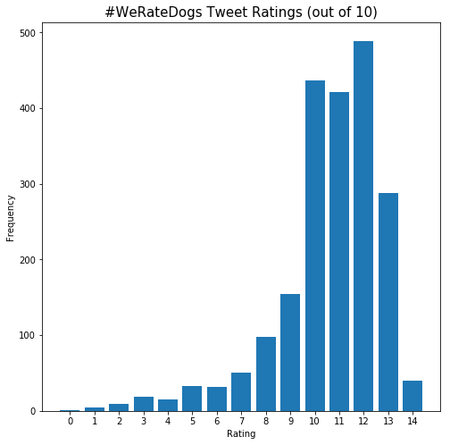

```python
# Plot a bar chart of ratings without outliers
rating_plot = rating_count[rating_count.index < 15]

plt.figure(figsize=(8, 8));
plt.bar(rating_plot.index, rating_plot);
plt.title("#WeRateDogs Tweet Ratings (out of 10)", size=15);
plt.xlabel("Rating");
plt.ylabel("Frequency");
plt.xticks(ticks=[i for i in range(15)]);
```

As shown in the bar chart above, the distribution follows a left skew (negative skew). Here, there is a gradually increasing frequency from ratings 0-7, followed by a rapid increase peaking at rating 12, and then fall sharply, with zero frequency at rating 15.

### How does Ratings affect the Average Retweet Count, and the Average Favorite Count?

From the previous bar chart, it can be seen that there were very few observations for ratings 0 (1 row) and 1 (4 rows). These will not give a fair representation of the average count, and therefore omitted in the following plots.

```python
# Retweets average
rating_retweets = df_dogs_master_copy.groupby("rating_numerator").retweet_count.mean()
rating_retweets
```

```
rating_numerator
0.00      3443.00
1.00      3122.50
2.00      1350.33
3.00      952.58
4.00      1105.67
5.00      1050.03
6.00      1043.62
7.00      1064.20
8.00      904.11
9.00      817.48
10.00     1563.54
11.00     2261.01
12.00     3136.91
13.00     6938.27
14.00     9493.83
420.00    4324.00
1776.00   2772.00
Name: retweet_count, dtype: float64
```

```python
# Favorite average
rating_favorite = df_dogs_master_copy.groupby("rating_numerator").favorite_count.mean()
rating_retweets
```

```
rating_numerator
0.00      3443.00
1.00      3122.50
2.00      1350.33
3.00      952.58
4.00      1105.67
5.00      1050.03
6.00      1043.62
7.00      1064.20
8.00      904.11
9.00      817.48
10.00     1563.54
11.00     2261.01
12.00     3136.91
13.00     6938.27
14.00     9493.83
420.00    4324.00
1776.00   2772.00
Name: retweet_count, dtype: float64
```

```python
# Ratings and average retweet counts without outliers and ratings below 2
ratings_retweets_plot = rating_retweets[(rating_retweets.index < 15) & (rating_retweets.index > 1)]

# Ratings and average favorite counts without outliers and ratings below 2
ratings_favorite_plot = rating_favorite[(rating_retweets.index < 15) & (rating_retweets.index > 1)]
```

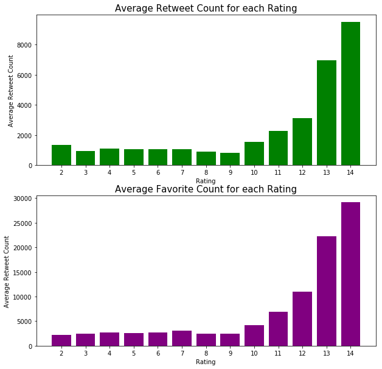

```python
# Plotting both graphs side by side
plt.figure(figsize=(10, 10));

# Ratings vs. Average Retweet Count
plt.subplot(211);
plt.bar(ratings_retweets_plot.index, ratings_retweets_plot, color="green");
plt.title("Average Retweet Count for each Rating", size=15);
plt.xlabel("Rating");
plt.ylabel("Average Retweet Count");
plt.xticks(ticks=[i for i in range(2, 15)]);

# Ratings vs. Average Favorite Count
plt.subplot(212);
plt.bar(ratings_favorite_plot.index, ratings_favorite_plot, color="purple");
plt.title("Average Favorite Count for each Rating", size=15);
plt.xlabel("Rating");
plt.ylabel("Average Retweet Count");
plt.xticks(ticks=[i for i in range(2, 15)]);
```

The above graphs show that both average retweet counts and favorite counts follow a very similar trend with ratings. From the ratings 2-9, the count is low and does not follow any pattern. From ratings 10 onwards, the counts appear to increase exponentially up to rating 14.

### What is the most common stages of dogs (ignoring multiple stage dogs)?

```python
dog_stages = df_dogs_master_copy.dog_stage.value_counts()[["doggo", "floofer", "pupper", "puppo"]]
dog_stages
```

```
doggo      72
floofer    9
pupper     220
puppo      23
Name: dog_stage, dtype: int64
```

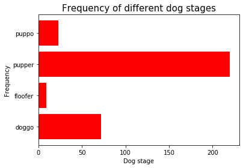

```python
plt.barh(dog_stages.index, dog_stages, color="red");
plt.title("Frequency of different dog stages", size=15);
plt.xlabel("Dog stage");
plt.ylabel("Frequency");
```

```python
# Total number of observations which contain information about dog stages
sum(dog_stages)
```

```
324
```

```python
# Proportions of observations with information about stages of dogs
sum(dog_stages)/df_dogs_master_copy.tweet_id.count()
```

```
0.15472779369627507
```

As shown above, only about 15% of all tweets contain information about the stages of the dogs. With this information, it can be shown that the most common type of dog is pupper, and least common type is floofer.

### How does the number of WeRateDogs tweets vary daily and monthly?

As shown below, the dataframes contain information of tweets across nearly two years, so a time series can be plotted.

```python
import datetime as dt
```

```python
df_dogs_master_copy.timestamp.max() - df_dogs_master_copy.timestamp.min()
```

```
Timedelta('624 days 17:51:48')
```

```python
# Create another copy of master to use for visualisation
df_dogs_master_copy2 = df_dogs_master_copy.copy()
```

```python
# Create new column with day-month-year for grouping
df_dogs_master_copy2["day_month_year"] = df_dogs_master_copy2["timestamp"].dt.to_period("D")
df_dogs_master_copy2[["timestamp", "day_month_year"]].head()
```

|  | timestamp | day_month_year |
| --- | --- | --- |
| 0 | 2017-08-01 16:23:56+00:00 | 2017-08-01 |
| 1 | 2017-08-01 00:17:27+00:00 | 2017-08-01 |
| 2 | 2017-07-31 00:18:03+00:00 | 2017-07-31 |
| 3 | 2017-07-30 15:58:51+00:00 | 2017-07-30 |
| 4 | 2017-07-29 16:00:24+00:00 | 2017-07-29 |

```python
# Groupby day and count
tweets_day = df_dogs_master_copy2.groupby("day_month_year").count()
tweets_day.head()
```

| day_month_year | tweet_id | timestamp | source | text | expanded_urls | rating_numerator | rating_denominator | name | retweet_count | favorite_count | ... | p1 | p1_conf | p1_dog | p2 | p2_conf | p2_dog | p3 | p3_conf | p3_dog | dog_stage |
| --- | --- | --- | --- | --- | --- | --- | --- | --- | --- | --- | --- | --- | --- | --- | --- | --- | --- | --- | --- | --- | --- |
| 2015-11-15 | 3 | 3 | 3 | 3 | 3 | 3 | 3 | 0 | 3 | 3 | ... | 3 | 3 | 3 | 3 | 3 | 3 | 3 | 3 | 3 | 0 |
| 2015-11-16 | 25 | 25 | 25 | 25 | 25 | 25 | 25 | 0 | 25 | 25 | ... | 25 | 25 | 25 | 25 | 25 | 25 | 25 | 25 | 25 | 0 |
| 2015-11-17 | 15 | 15 | 15 | 15 | 15 | 15 | 15 | 7 | 15 | 15 | ... | 15 | 15 | 15 | 15 | 15 | 15 | 15 | 15 | 15 | 0 |
| 2015-11-18 | 17 | 17 | 17 | 17 | 17 | 17 | 17 | 11 | 17 | 17 | ... | 17 | 17 | 17 | 17 | 17 | 17 | 17 | 17 | 17 | 0 |
| 2015-11-19 | 23 | 23 | 23 | 23 | 23 | 23 | 23 | 14 | 23 | 23 | ... | 23 | 23 | 23 | 23 | 23 | 23 | 23 | 23 | 23 | 0 |

5 rows × 22 columns

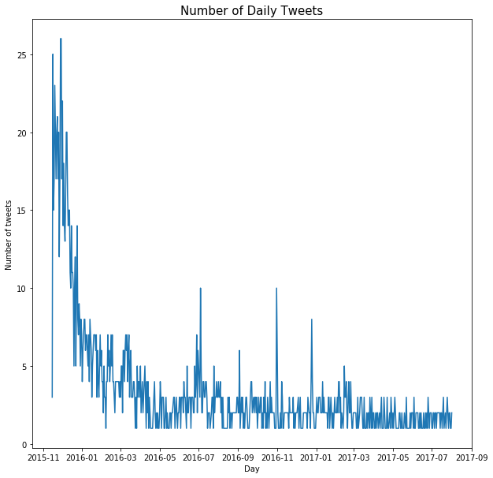

```python
# Plot how the number of daily tweets changes
plt.figure(figsize=(10, 10));
#matplotlib requires dates to be in timestamp format
plt.plot(tweets_day.index.to_timestamp(), tweets_day.tweet_id);
plt.title("Number of Daily Tweets", size=15);
plt.xlabel("Day");
plt.ylabel("Number of tweets");
```

As expected, the variations in the number of tweets posted daily fluctuate wildly and it is difficult to see a trend. Thus, the number of tweets posted month will be analysed.

```python
# Create new column with month-year for grouping
df_dogs_master_copy2["month_year"] = df_dogs_master_copy2["timestamp"].dt.to_period("M")
tweets_month = df_dogs_master_copy2.groupby("month_year").count()
tweets_month.head()
```

| month_year | tweet_id | timestamp | source | text | expanded_urls | rating_numerator | rating_denominator | name | retweet_count | favorite_count | ... | p1_conf | p1_dog | p2 | p2_conf | p2_dog | p3 | p3_conf | p3_dog | dog_stage | day_month_year |
| --- | --- | --- | --- | --- | --- | --- | --- | --- | --- | --- | --- | --- | --- | --- | --- | --- | --- | --- | --- | --- | --- |
| 2015-11 | 296 | 296 | 296 | 296 | 296 | 296 | 296 | 177 | 296 | 296 | ... | 295 | 295 | 295 | 295 | 295 | 295 | 295 | 295 | 0 | 296 |
| 2015-12 | 372 | 372 | 372 | 372 | 372 | 372 | 372 | 222 | 372 | 372 | ... | 360 | 360 | 360 | 360 | 360 | 360 | 360 | 360 | 66 | 372 |
| 2016-01 | 183 | 183 | 183 | 183 | 183 | 183 | 183 | 113 | 183 | 183 | ... | 166 | 166 | 166 | 166 | 166 | 166 | 166 | 166 | 46 | 183 |
| 2016-02 | 120 | 120 | 120 | 120 | 120 | 120 | 120 | 76 | 120 | 120 | ... | 108 | 108 | 108 | 108 | 108 | 108 | 108 | 108 | 22 | 120 |
| 2016-03 | 132 | 132 | 132 | 132 | 132 | 132 | 132 | 91 | 132 | 132 | ... | 118 | 118 | 118 | 118 | 118 | 118 | 118 | 118 | 12 | 132 |

5 rows × 23 columns

```python
tweets_month["tweet_id"]
```

```
month_year
2015-11    296
2015-12    372
2016-01    183
2016-02    120
2016-03    132
2016-04    60
2016-05    59
2016-06    90
2016-07    96
2016-08    61
2016-09    69
2016-10    71
2016-11    54
2016-12    57
2017-01    69
2017-02    67
2017-03    52
2017-04    42
2017-05    43
2017-06    48
2017-07    51
2017-08    2
Freq: M, Name: tweet_id, dtype: int64
```

2017-08 does not contain many tweets because the data frame contains tweets from 1 August 2017 only. Thus, these tweets will be removed for further visualisations.

```python
# Using Boolean indexing, tweets from August 2017 will be removed
tweets_month = tweets_month[tweets_month.index < "2017-08"]
tweets_month["tweet_id"]
```

```
month_year
2015-11    296
2015-12    372
2016-01    183
2016-02    120
2016-03    132
2016-04    60
2016-05    59
2016-06    90
2016-07    96
2016-08    61
2016-09    69
2016-10    71
2016-11    54
2016-12    57
2017-01    69
2017-02    67
2017-03    52
2017-04    42
2017-05    43
2017-06    48
2017-07    51
Freq: M, Name: tweet_id, dtype: int64
```

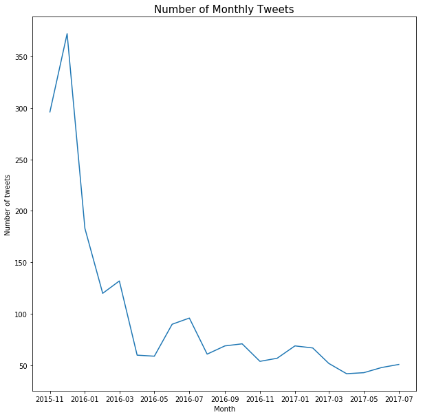

```python
# Plot how the number of monthtly tweets changes
plt.figure(figsize=(10, 10));
plt.plot(tweets_month.index.to_timestamp(), tweets_month.tweet_id);
plt.title("Number of Monthly Tweets", size=15);
plt.xlabel("Month");
plt.ylabel("Number of tweets");
```

As shown in the graph above, the number of tweets is highest at the end of year 2015 (over 300). Then, the monthly number of tweets have decreased exponentially until around May 2016. The number of tweets experience a slight increase in June and July 2016 (80-100 tweets). Then it drops and fluctuate between around 40 and 70 tweets ever since. This plot show that the number of #WeRateDogs tweets have fallen, as it may have lost popularity since 2016.

### Tweets from which month has the highest average WeRateDogs *retweets* and *favorite counts*?

As daily number of tweets vary and would not provide a fair average number of retweets, the tweets are grouped by months. Then, the average number of retweets and favorites are calculated and visualised.

```python
# Minimum number of tweets in a month
tweets_month.tweet_id.min()
```

```
42
```

The minimum number of tweets is 42, which is sufficient to calculate the average retweets and favourite counts.

```python
# Group by month and find mean retweet counts
retweets_mean = df_dogs_master_copy2.groupby("month_year").retweet_count.mean()
retweets_mean
```

```
month_year
2015-11   543.76
2015-12   1563.53
2016-01   1664.22
2016-02   1552.48
2016-03   1768.30
2016-04   1627.90
2016-05   2247.68
2016-06   4131.99
2016-07   2830.53
2016-08   3616.89
2016-09   3616.35
2016-10   4678.69
2016-11   4810.87
2016-12   5618.82
2017-01   6193.09
2017-02   4334.67
2017-03   4961.27
2017-04   5762.55
2017-05   7514.16
2017-06   6547.42
2017-07   7093.24
2017-08   7683.50
Freq: M, Name: retweet_count, dtype: float64
```

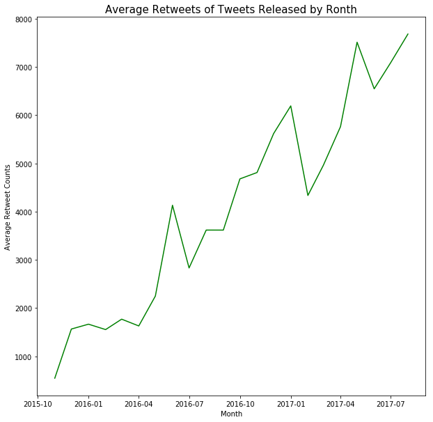

```python
# Plotting average retweets
plt.figure(figsize=(10, 10));
plt.plot(retweets_mean.index.to_timestamp(), retweets_mean, color="green");
plt.title("Average Retweets of Tweets Released by Ronth", size=15);
plt.xlabel("Month");
plt.ylabel("Average Retweet Counts");
```

```python
# Group by month and find mean favourite counts
favorite_mean = df_dogs_master_copy2.groupby("month_year").favorite_count.mean()
favorite_mean
```

```
month_year
2015-11   1241.79
2015-12   3583.07
2016-01   4179.50
2016-02   4128.88
2016-03   4692.21
2016-04   4668.38
2016-05   6215.95
2016-06   9396.94
2016-07   7446.79
2016-08   10154.11
2016-09   11103.75
2016-10   13917.96
2016-11   14593.61
2016-12   16404.93
2017-01   19075.46
2017-02   18304.00
2017-03   20662.69
2017-04   22972.52
2017-05   28849.60
2017-06   28871.02
2017-07   32420.96
2017-08   36643.00
Freq: M, Name: favorite_count, dtype: float64
```

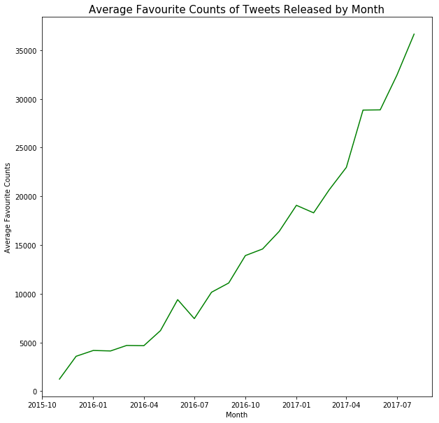

```python
# Plotting average favourite counts
plt.figure(figsize=(10, 10));
plt.plot(favorite_mean.index.to_timestamp(), favorite_mean, color="green");
plt.title("Average Favourite Counts of Tweets Released by Month", size=15);
plt.xlabel("Month");
plt.ylabel("Average Favourite Counts");
```

### Is there a correlation between the number of monthly tweets and its corresponding average retweet counts?

Below, the number of monthly tweets are compared with the average retweet counts for those tweets released in that month. It will be interesting to see if the number of monthly tweets affect the retweet counts.

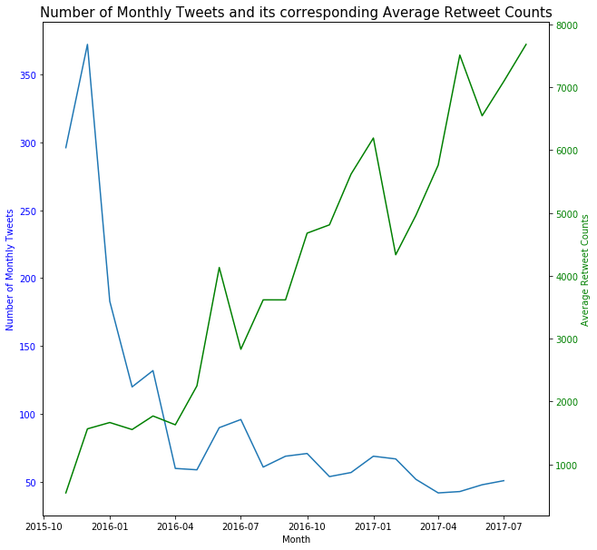

```python
# Plotting both graphs with different axes require creating an axis object
fig, ax1 = plt.subplots(figsize=(10, 10));
plt.title("Number of Monthly Tweets and its corresponding Average Retweet Counts", size=15)
ax1.set_xlabel("Month");

# First axes object for monthly tweets
ax1.set_ylabel("Number of Monthly Tweets", color="blue");
ax1.plot(tweets_month.index.to_timestamp(), tweets_month.tweet_id);
ax1.tick_params(axis="y", labelcolor="blue");

# create a second axes that shares the same x-axis for average retweet counts
ax2 = ax1.twinx()
ax2.set_ylabel("Average Retweet Counts", color="green");
ax2.plot(retweets_mean.index.to_timestamp(), retweets_mean, color="green");
ax2.tick_params(axis="y", labelcolor="green");
```

As shown by the plot above, there appears to be an inverse relationship between the number monthly tweets and the corresponding retweet counts. As the number of monthly retweets decrease, the corresponding average retweet counts increases. This does not indicate that the WeRateDogs tweets lose popularity. Rather - with the number of monthly tweets decreasing, the quality of these tweets may have increased, evident by an increase in retweet counts. That being said, both monthly tweets and retweet counts may not influence each other directly. Further analysis may be required to establish whether one truly affects the other.

### How many images are most commonly posted in each tweet?

```python
img_count = df_dogs_master_copy2.groupby("img_num").count()
img_count
```

| img_num | tweet_id | timestamp | source | text | expanded_urls | rating_numerator | rating_denominator | name | retweet_count | favorite_count | ... | p1_dog | p2 | p2_conf | p2_dog | p3 | p3_conf | p3_dog | dog_stage | day_month_year | month_year |
| --- | --- | --- | --- | --- | --- | --- | --- | --- | --- | --- | --- | --- | --- | --- | --- | --- | --- | --- | --- | --- | --- |
| 1.00 | 1692 | 1692 | 1692 | 1692 | 1692 | 1691 | 1691 | 1174 | 1692 | 1692 | ... | 1692 | 1692 | 1692 | 1692 | 1692 | 1692 | 1692 | 249 | 1692 | 1692 |
| 2.00 | 190 | 190 | 190 | 190 | 190 | 190 | 190 | 136 | 190 | 190 | ... | 190 | 190 | 190 | 190 | 190 | 190 | 190 | 34 | 190 | 190 |
| 3.00 | 59 | 59 | 59 | 59 | 59 | 59 | 59 | 38 | 59 | 59 | ... | 59 | 59 | 59 | 59 | 59 | 59 | 59 | 13 | 59 | 59 |
| 4.00 | 30 | 30 | 30 | 30 | 30 | 30 | 30 | 24 | 30 | 30 | ... | 30 | 30 | 30 | 30 | 30 | 30 | 30 | 7 | 30 | 30 |

4 rows × 23 columns

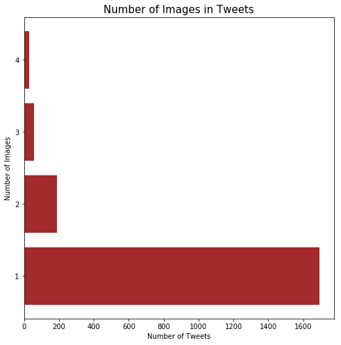

```python
plt.figure(figsize=(8,8));
plt.barh(img_count.index, img_count.tweet_id, color="brown");
plt.title("Number of Images in Tweets", size=15);
plt.xlabel("Number of Tweets");
plt.ylabel("Number of Images");
plt.yticks([tick for tick in range(1, 5)]);
```

The most common number of images posted is one. This is as expected since one image per tweet tend to give the image more credit and recognition.

### Lastly, what is the index of the picture with the highest number favourite counts?

```python
fav_max = df_dogs_master_copy.favorite_count.max()
fav_max_row = df_dogs_master_copy[df_dogs_master_copy.favorite_count == fav_max]
fav_max_row
```

|  | tweet_id | timestamp | source | text | expanded_urls | rating_numerator | rating_denominator | name | retweet_count | favorite_count | ... | p1 | p1_conf | p1_dog | p2 | p2_conf | p2_dog | p3 | p3_conf | p3_dog | dog_stage |
| --- | --- | --- | --- | --- | --- | --- | --- | --- | --- | --- | --- | --- | --- | --- | --- | --- | --- | --- | --- | --- | --- |
| 413 | 822872901745569793 | 2017-01-21 18:26:02+00:00 | <a href="http://twitter.com/download/iphone" rel="nofollow">Twitter for iPhone</a> | Here's a super supportive puppo participating in the Toronto #WomensMarch today. 13/10 https://t.co/nTz3FtorBc | https://twitter.com/dog_rates/status/822872901745569793/photo/1 | 13.00 | 10.00 | NaN | 48265.00 | 132810.00 | ... | Lakeland_terrier | 0.20 | True | Labrador_retriever | 0.16 | True | Irish_terrier | 0.07 | True | puppo |

1 rows × 22 columns